# Healthcare Analytics Challenges: A Three-Pillar Framework Connecting Analytics Maturity, Workforce Agility, and Technical Enablement

Samuel T Harrold, Yuimedi, Inc.

January 2026

Abstract

**Background:** Healthcare organizations face three interconnected challenges: low analytics maturity, with only 39 organizations globally having achieved HIMSS AMAM Stage 6-7; systemic instability from high leadership turnover (53% of CIOs with <3 years tenure) and persistent digital skills shortages; and technical barriers in natural language to SQL generation. When these challenges interact, they create institutional memory loss that threatens data-driven healthcare transformation.

**Objective:** This research develops a three-pillar analytical framework connecting analytics maturity, workforce agility, and technical enablement. The framework reveals how these capabilities interconnect and compound each other.

**Methods:** We conducted a narrative literature review of peer-reviewed studies and industry reports on natural language to SQL (NL2SQL) generation, healthcare analytics maturity, and workforce turnover. Grey literature was assessed using the AACODS checklist. Evidence was synthesized through the three-pillar analytical framework to examine how these challenges interconnect and compound.

**Results:** Healthcare-specific text-to-SQL benchmarks show significant progress, though current models are “not yet sufficiently accurate for unsupervised use” in clinical settings. Most healthcare organizations remain at HIMSS AMAM Stages 0-3 with limited predictive capabilities. Healthcare IT turnover significantly exceeds other IT sectors, creating measurable institutional memory loss. The framework reveals a compounding dynamic: low-maturity organizations experience higher turnover, which degrades the institutional knowledge needed for maturity advancement, while technical barriers prevent the capture of expertise before it is lost.

**Conclusions:** We contribute a three-pillar analytical framework synthesizing evidence on analytics maturity, workforce agility, and technical enablement. The framework reveals a compounding effect: low maturity accelerates turnover, which degrades maturity, and low enablement prevents recovery. This analytical lens enables organizational self-assessment and informs future research on technological interventions, such as conversational AI platforms.

# 1 Introduction

## 1.1 The Compounding Crisis in Healthcare Analytics

Healthcare organizations face three critical, interconnected challenges that form a compounding crisis, collectively threatening their ability to become data-driven enterprises. Unlike technology or financial services, healthcare combines complex clinical workflows, extensive regulatory requirements, and a workforce with limited technical training but deep domain expertise (1). This paper introduces a three-pillar framework that examines how these challenges interconnect and reinforce one another.

The framework follows a logical progression from observation to root cause:

1. *Pillar 1: Low Analytics Maturity (The Observation):* The most visible symptom is healthcare’s struggle to advance its analytics capabilities. Despite massive investments in data infrastructure, most organizations remain at low maturity levels, unable to leverage their data for predictive or prescriptive insights.
2. *Pillar 2: Workforce Instability (The Cause):* This low maturity is not a static state but is actively driven by a systemic workforce crisis. High turnover at leadership, operational, and specialized levels creates a constant drain of institutional knowledge, preventing the accumulation of expertise required for maturity advancement.
3. *Pillar 3: Technical Barriers (The Root Mechanism):* The cycle is perpetuated by technical barriers that prevent organizations from capturing expertise before it is lost. The gap between clinical domain experts and the technical skills required for data access (e.g., SQL) creates a dependency on a small pool of specialists, making the system fragile and vulnerable to knowledge loss.

This introduction will now examine the evidence for each of these pillars in turn, establishing the foundation for the integrated framework that is the central contribution of this paper.

## 1.2 Pillar 1: Low Healthcare Analytics Maturity

The Healthcare Information Management Systems Society (HIMSS) Analytics Maturity Assessment Model (AMAM) provides the industry standard for measuring analytics capabilities. Recent assessments reveal a sobering reality: as of late 2024, only 26 organizations worldwide had achieved Stage 6 maturity, with merely 13 reaching Stage 7 (2,3). Despite this progress, the vast majority of organizations remain at Stages 0-3, characterized by fragmented data, limited automated reporting, and minimal predictive capabilities (2). This low maturity severely constrains evidence-based decision making.

## 1.3 Pillar 2: Institutional Memory Loss from Workforce Instability

Healthcare faces an institutional memory crisis that has evolved from simple turnover to systemic instability. This crisis unfolds at three levels:

- *Strategic Level:* Leadership churn is acute, with 53% of healthcare CIOs having a tenure of less than three years, leading to frequent shifts in analytics strategy (4).
- *Operational Level:* 79% of healthcare provider organizations report persistent shortages in “Information and Digital Health” roles, leaving critical technical positions vacant (5).
- *Foundational Level:* A 2025 analysis found that 55% of public health informatics specialists intended to leave their positions, preventing the accumulation of the tacit knowledge needed to maintain analytics infrastructure (6).

This multi-layered churn creates a cascade of knowledge loss. When experienced analysts leave, they take with them irreplaceable tacit knowledge: business rules, data anomalies, and analytical context that traditional documentation fails to capture. The challenge is not new; a foundational 2004 study established that healthcare IT staff had the lowest expected tenure for new hires among all IT sectors at just 2.9 years (7). That this two-decade-old study remains a key benchmark is itself evidence of the crisis: the industry is so unstable it has lost the ability to track its own attrition.

## 1.4 Pillar 3: Technical Barriers to Data Access

Against this backdrop of organizational immaturity and workforce instability, technical barriers perpetuate the cycle. Accessing healthcare insights requires navigating a complex technical landscape. While the immediate barrier is often the “technical skills gap”—where clinical experts lack SQL expertise—this is merely the surface of deeper challenges in semantic interoperability and data quality (8,9).

In this context, Natural Language to SQL (NL2SQL) generation is not a “magic bullet” but a democratizing interface layer and a governance forcing function. For an AI system to translate a natural language question into a correct SQL query, technical prerequisites must be met: validated data models, explicit business logic, and codified definitions. The AI interface forces the organization to make this knowledge explicit, moving it from the minds of a few experts into a durable, shared system. It provides a bridge that allows non-technical domain experts to interact with data *alongside* these modernization efforts, unlocking value from imperfect systems while broader interoperability efforts continue (10–13).

The implications of these three interconnected challenges are measurable in both operational and clinical terms. When analytics barriers are addressed, outcomes improve substantially: one Medicare ACO reduced readmission rates from 24% to 17.8% and achieved $1.6 million in cost savings by implementing data analytics to overcome EHR fragmentation (14). Yet, barriers remain pervasive, with 68% of healthcare organizations citing data interoperability as the leading obstacle, followed by privacy concerns (64%) and insufficient staff training (59%) (15). Adoption of big data analytics faces validated barriers including employee resistance to change and lack of organizational readiness, which directly stall data-driven initiatives (16,17). Together, these three pillars represent a compounding cycle of operational inefficiencies with demonstrated implications for healthcare delivery.

## 1.5 Objectives

This research aims to develop a framework for understanding healthcare’s interconnected analytics challenges. The specific objectives are as follows:

### 1.5.1 Primary Objective

Develop and validate a three-pillar analytical framework that explains how analytics maturity, workforce agility, and technical enablement interconnect and compound each other.

### 1.5.2 Secondary Objectives

1. *Synthesize current evidence* on natural language to SQL generation as a technical barrier.
2. *Document the extent* of analytics maturity challenges in healthcare organizations globally.
3. *Quantify the impact* of workforce turnover on institutional memory and analytics capabilities.
4. *Reveal interconnections* between the three pillars through evidence synthesis.
5. *Provide an assessment rubric* for organizational self-evaluation.

### 1.5.3 Non-Goals

This research does not address:

- Specific vendor comparisons or product recommendations.
- Implementation details for particular healthcare IT environments.
- Regulatory compliance strategies for specific jurisdictions.
- Technical architecture specifications for conversational AI systems.

*Note: Analysis of market dynamics and structural factors explaining why institution-specific analytics challenges persist is within the scope of this paper. This market-level analysis provides context for evaluating solution approaches and differs from product comparisons, which would evaluate or recommend specific vendor offerings.*

## 1.6 Contributions

This paper makes the following contributions to the healthcare informatics literature:

1. *Three-Pillar Analytical Framework*: We synthesize evidence from three disconnected research domains—healthcare analytics maturity, workforce turnover, and natural language processing—into a unified analytical framework. This framework reveals how these challenges interconnect and compound each other: low maturity accelerates turnover, turnover degrades agility, and low technical enablement prevents recovery. The framework provides a lens for organizational self-assessment and research prioritization.
2. *Evidence Synthesis*: We document the current state of each pillar through a comprehensive literature review, providing healthcare organizations with consolidated evidence on analytics maturity benchmarks, the impact of workforce turnover, and NL2SQL technical capabilities.
3. *Illustrative Application*: Drawing on established knowledge management literature, we describe the validated query cycle as an example of how the framework can inform technology design. This concept addresses institutional memory loss through a six-step process that allows domain experts to validate and store queries, ensuring that knowledge persists independently of staff tenure. Figures 1 and 2 illustrate this architecture and cycle.

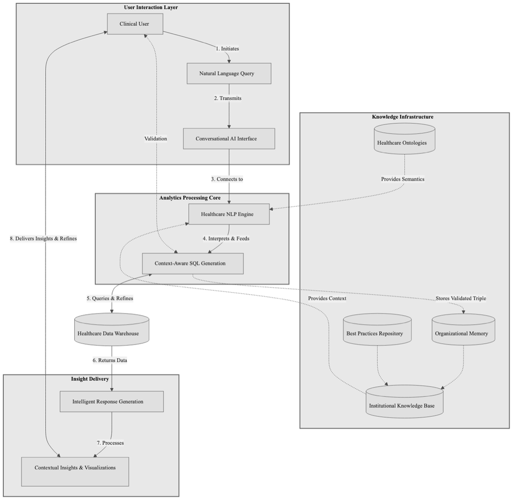

Healthcare Analytics Architecture. Solid lines indicate the primary data flow from clinical user natural language queries through a conversational AI interface to a healthcare NLP engine for context-aware SQL generation. Bi-directional arrows at steps 5 and 8 represent the iterative ‘Query & Refine’ loop where users refine their intent based on delivered insights. The critical validation step (dotted bi-directional line) shows domain experts confirming or correcting generated SQL before results are trusted. Validated NL-SQL-Rationale triples flow to organizational memory (dashed line), where they persist independent of staff tenure and inform future query generation.

### 1.6.1 Illustrative Application: The Validated Query Cycle as a Governance Forcing Function

To demonstrate how the three-pillar framework might inform technology design, we describe a validated query cycle. This cycle functions as a *Governance Forcing Function*, a mechanism that uses technical implementation to compel the adoption of stronger data governance practices. It directly addresses institutional memory loss (Pillar 2) by systematically converting tacit knowledge into an explicit, durable asset, thereby reducing technical barriers (Pillar 3) and enabling organizations to advance their analytics maturity (Pillar 1).

The six-step cycle (Figure 2) illustrates this approach:

1. *Query*: A domain expert (clinician, analyst, or administrator) asks a natural language question, such as, “What was our 30-day readmission rate for heart failure patients last quarter?”
2. *Generation*: The conversational AI system generates candidate SQL code, leveraging healthcare ontologies and organizational schema knowledge.
3. *Validation*: The AI provides a natural language explanation of the SQL logic and results, allowing the domain expert to validate the query’s intent without reviewing raw code. This human-in-the-loop step aligns with “Human-on-the-Loop” (HotL) frameworks, transforming validation from a binary check into an iterative knowledge capture process (18,19). This is essential given that current models are “not yet sufficiently accurate for unsupervised use” in clinical settings (20).
4. *Storage*: Once validated, the NL-SQL-Rationale triple is stored in organizational memory as a durable knowledge artifact. The Rationale Metadata documents the query’s business logic (e.g., “Excluding Hospice per 2025 CMS rules”) and is a mandatory component of the triple.
5. *Retrieval*: When future users ask similar questions, the system retrieves relevant validated triples, reducing dependence on individual expertise.
6. *Persistence*: When the original expert leaves, their analytical knowledge remains embedded in the system. New staff inherit executable knowledge rather than starting from scratch.

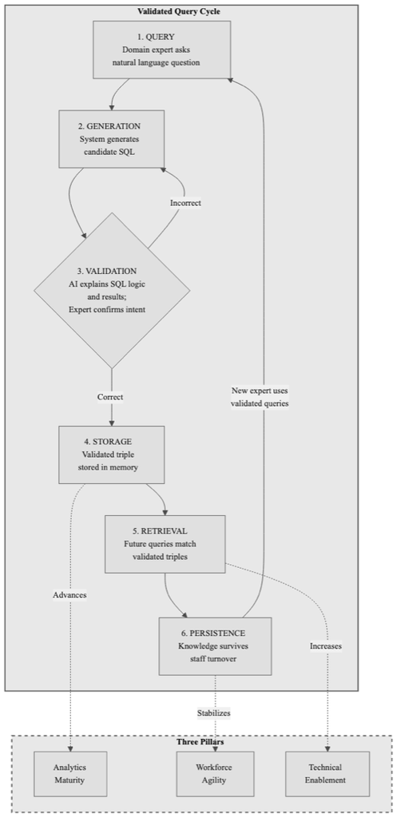

The Validated Query Cycle, shown as six numbered steps in the diagram. (1) Domain experts ask natural language questions, (2) the system generates candidate SQL, (3) AI provides a natural language explanation of the SQL logic; domain expert confirms the intent and results, (4) validated triples are stored, (5) future queries retrieve validated knowledge, and (6) expertise persists through staff turnover. This cycle breaks the compounding effect where turnover erases institutional memory.

This cycle breaks the compounding effect identified in the three-pillar framework: turnover no longer erases analytical knowledge because expertise is embedded in validated query triples rather than individual memory. Low-maturity organizations can accelerate advancement by accumulating validated queries, and technical barriers are reduced because new staff access proven query patterns rather than recreating analytical logic.

## 1.7 Document Structure

Following this introduction, the paper proceeds through five main sections. The Methodology section describes the narrative review approach, literature search strategy, and source selection criteria. The Framework Development section documents how the three-pillar framework emerged from the literature and its theoretical grounding. The Literature Review synthesizes evidence across the three pillar domains: natural language to SQL generation, analytics maturity, and workforce dynamics. The Discussion examines implications, limitations, and future research directions. Finally, the Conclusion summarizes the three-pillar analytical framework as this paper’s primary contribution to healthcare informatics literature.

# 2 Methodology

## 2.1 Review Approach

This paper employs a narrative review methodology to synthesize evidence across the three pillars of the framework: analytics maturity, workforce agility, and technical enablement (specifically natural language to SQL generation). Unlike systematic reviews that follow pre-registered protocols with exhaustive searches, narrative reviews provide expert synthesis of relevant literature to construct coherent arguments and identify patterns across diverse evidence sources.

The narrative review approach was selected because:

1. *Integration across domains*: The paper synthesizes evidence from distinct fields (clinical informatics, human resources, natural language processing) that require interpretive integration rather than statistical pooling
2. *Original analytical framework*: The three-pillar framework emerged iteratively from the literature rather than being pre-specified
3. *Heterogeneous evidence types*: The evidence base includes peer-reviewed research, industry reports, and benchmark datasets that cannot be meaningfully combined through meta-analysis

## 2.2 Stage 1: Identification and Targeted Queries

Literature was identified through multiple channels between January 2023 and December 2025:

Academic Databases:

- Crossref: Cross-disciplinary academic literature, citation metadata
- PubMed: Clinical informatics, healthcare workforce, medical administration
- arXiv: Machine learning and NLP preprints, benchmark studies
- Semantic Scholar: AI and computer science papers, citation analysis

Industry Sources:

- HIMSS: Analytics Maturity Model documentation and industry standards
- Healthcare providers: NHS Trust implementation case studies
- Market research: Precedence Research, Forrester analyst reports
- Technology vendors: Health Catalyst, Oracle, Anthropic technical documentation
- Professional associations: AHIMA/NORC workforce surveys
- Business news: IBM, CNBC coverage of healthcare analytics ventures

Search Concepts and Results:

Search terms emerged iteratively and were organized around the three-pillar framework. Table 1 summarizes the search concepts and results by source.

Initial search results by database source. Numbers in parentheses indicate studies passing initial screening. Search concepts: Analytics Maturity (“healthcare analytics maturity”, “HIMSS AMAM”, “analytics adoption”, “big data analytics adoption”, “resistance to change”, “analytics standardization failure”, “low-code ROI”); Workforce Agility (“healthcare IT tenure”, “IT training time”, “turnover cost”, “institutional memory loss”, “organizational forgetting”, “competence loss”, “knowledge portal”, “SECI model”); Technical Enablement (“NL2SQL healthcare”, “text-to-SQL clinical”, “MIMICSQL”, “EHRSQL”, “schema discovery”, “semantic column matching”, “vector embeddings”).

[output not shown]

Figure 3 illustrates the literature selection process, showing progression from initial database search through screening and quality assessment to the final corpus of included sources.

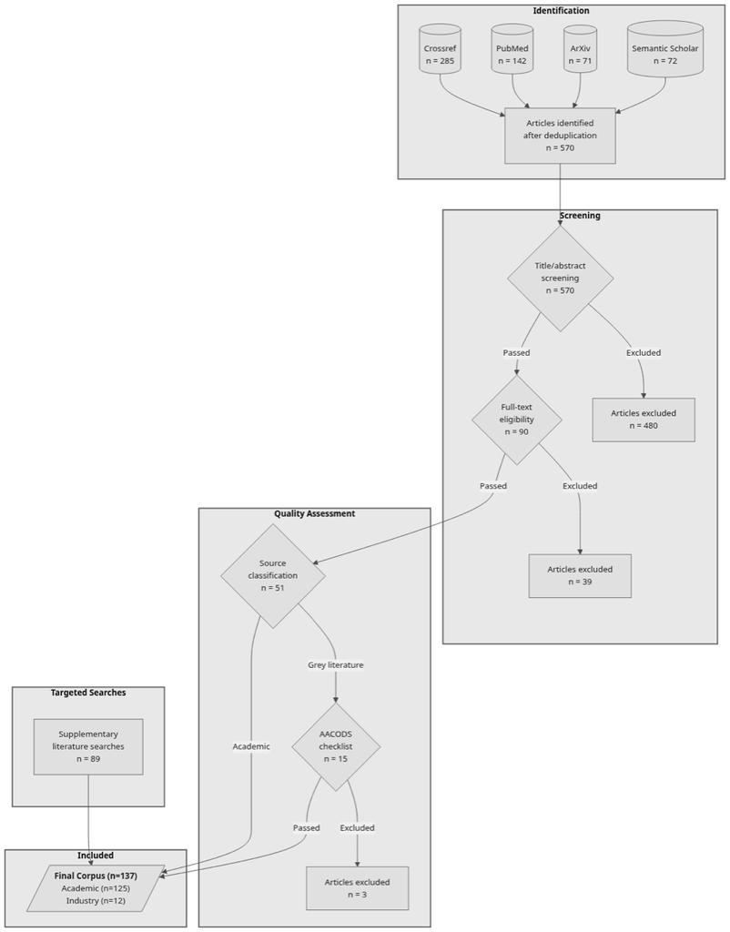

Literature Selection Flow Diagram. The diagram shows the progression from initial database search (n ≈ 570) through title/abstract screening, full-text review, and quality assessment (AACODS for grey literature) to the final corpus of 137 sources (125 academic, 12 industry). Diagram source available in figures/literature-flow.mmd.

## 2.3 Stage 2: Screening and Selection

Sources were selected based on the following criteria:

Inclusion Criteria:

- Peer-reviewed publications in healthcare informatics, medical informatics, computer science, or health services research
- Industry reports from established healthcare IT organizations (HIMSS, AHIMA, AMIA)
- Publications from 2015-current, with emphasis on 2020-current for rapidly evolving NL2SQL technologies
- English language publications
- Sources with verifiable DOIs, URLs, or institutional attribution

Exclusion Criteria:

- Sources without verifiable attribution or institutional backing
- Vendor marketing materials without independent validation
- Preprints without subsequent peer-reviewed publication (exception: foundational NL2SQL benchmarks where peer review is pending)
- Studies with unverifiable statistics or methodological concerns

## 2.4 Stage 3: Quality Assessment

Grey literature sources were assessed using the AACODS checklist (21), which evaluates Authority, Accuracy, Coverage, Objectivity, Date, and Significance. Sources with vendor sponsorship were retained when no independent alternative existed but flagged in-text. Table 2 summarizes the assessment.

AACODS Assessment of Industry Sources.

| Source (Citation) | Authority / Accuracy | Coverage / Objectivity | Date / Significance | Include |
| --- | --- | --- | --- | --- |
| HIMSS AMAM (2) | High† / Verifiable | Global / High | 2024 / High | Yes |
| Snowdon / HIMSS (22) | High‡ / Verifiable | N/A / High | 2024 / Medium | Yes |
| Health Catalyst (23) | Medium§ / Unverifiable | US / Low | 2020 / Medium | Yes* |
| Berkshire NHS (24) | High¶ / Verifiable | Single site / High | 2024 / High | Yes |
| Forrester / Microsoft (25) | Medium∥ / Unverifiable | Enterprise / Low♢ | 2024 / Medium | Yes* |
| Oracle (26) | Low§ / Unverifiable | N/A / Low | 2024 / Low | Yes* |
| Precedence Research (27) | Medium# / Unverifiable | Global / Medium | 2024 / Medium | Yes |
| Anthropic (10) | Medium§ / Verifiable | N/A / Medium | 2025 / Low | Yes |
| IBM Newsroom (28) | High / Verifiable | N/A / High | 2022 / High | Yes |
| CNBC / Haven (29) | High / Verifiable | N/A / High | 2021 / High | Yes |
| AHIMA / NORC (1) | High†† / Verifiable | US / High | 2023 / High | Yes |

†Industry standards body. ‡HIMSS officer. §Vendor. ¶NHS trust. ∥Analyst firm. #Market research. Journalism. ††Professional association + academic. ♢Sponsor. *Vendor sponsorship or low objectivity noted in manuscript text.

## 2.5 Stage 4: Synthesis and Analysis

Reflecting the framework’s iterative emergence from the literature, evidence is synthesized thematically below:

1. Analytics maturity: Evidence on HIMSS AMAM adoption, healthcare analytics capabilities, and organizational readiness
2. Workforce turnover: Evidence on nursing and IT staff turnover rates, institutional memory loss, and knowledge transfer challenges
3. Technical barriers: Evidence on NL2SQL benchmarks, healthcare-specific NLP challenges, and low-code implementation patterns

This framework emerged iteratively from the literature rather than being pre-specified, consistent with narrative review methodology.

## 2.6 Methodological Limitations

This narrative review has inherent limitations:

- *Non-exhaustive search*: Literature identification was selective rather than exhaustive; relevant studies may have been missed
- *Limited formal quality assessment*: Grey literature sources were assessed using the AACODS checklist; however, no standardized quality assessment tool (e.g., GRADE, Cochrane Risk of Bias) was applied to peer-reviewed sources, as these tools are designed for clinical intervention studies rather than narrative reviews
- *Single-coder bias risk*: Literature screening, data extraction, and thematic analysis were performed by a single author without independent verification. This introduces potential selection and interpretation bias that would be mitigated in systematic reviews through dual-coder protocols with inter-rater reliability assessment
- *Post-hoc selection criteria*: Inclusion and exclusion criteria were refined during the review process rather than pre-registered
- *No protocol registration*: This review was not registered in PROSPERO or similar registries
- *Dated workforce statistics*: The primary healthcare IT turnover statistic (~34% implied for new hires) derives from Ang and Slaughter’s 2004 study (7). While recent surveys confirm workforce challenges persist (1) and contemporary evidence suggests the situation may have worsened (55% intent to leave among public health informatics specialists (6)), no study has directly replicated the 2004 tenure measurement methodology. This paper reframes this “data desert” as evidence of the crisis itself: the industry is too unstable to track its own attrition effectively. Future research should address this methodological gap.

These limitations are balanced against the strengths of narrative review methodology: ability to synthesize heterogeneous evidence types across disciplinary boundaries, flexibility to pursue emerging themes, and capacity to construct novel analytical frameworks that illuminate connections between previously disconnected research domains.

# 3 Framework Development and Validation

This paper’s primary contribution is the three-pillar analytical framework for understanding healthcare analytics challenges: (1) analytics maturity, (2) workforce agility, and (3) technical enablement. This section documents the framework’s development process and theoretical grounding.

## 3.1 Framework Development Process

The three-pillar framework emerged through iterative analysis of the literature corpus. Initial review identified numerous disconnected research streams: NL2SQL technical advances, HIMSS maturity models, healthcare workforce turnover studies, knowledge management theory, and healthcare IT implementation case studies. These appeared as isolated topics until thematic analysis revealed recurring patterns of interdependence.

The framework development followed these steps:

1. *Theme Extraction*: Systematic coding of included sources identified recurring themes across technical, organizational, and workforce dimensions
2. *Pattern Recognition*: Cross-domain analysis revealed that challenges in each dimension amplified challenges in others. A root cause analysis (observation-why-repeat) determined the framework’s ordering: low Analytics Maturity (Observation/Context) is driven by low Workforce Agility (Cause/Actor), which in turn is exacerbated by low Technical Enablement (Root Mechanism/Tool). This causal chain frames the three pillars, drawing on established RCA methodology for organizational learning (30,31).
3. *Pillar Identification*: Three orthogonal yet interconnected dimensions emerged as the organizing structure:
   - *Analytics Maturity*: Organizational capability progression measured against HIMSS AMAM stages
   - *Workforce Agility*: Human capital retention and tacit knowledge preservation
   - *Technical Enablement*: NL2SQL capabilities and healthcare-specific implementation solutions
4. *Framework Validation*: Pillar structure tested against the full corpus to confirm comprehensive coverage without significant gaps

## 3.2 Theoretical Grounding

The three-pillar framework aligns with established models in healthcare informatics and knowledge management:

| Three Pillars | HIMSS AMAM Alignment | DIKW Hierarchy | Knowledge Management |
| --- | --- | --- | --- |
| Analytics Maturity | Stages 0-7 Progression | Data $→$ Information | Organizational Learning |
| Workforce Agility | Implicit in Advanced Stages | Knowledge (tacit) $→$ Wisdom | Tacit Knowledge Transfer |
| Technical Enablement | Stages 6-7 Requirements | Information $→$ Knowledge | Knowledge Codification |

Table 3: Framework Alignment with Established Models

The HIMSS Analytics Maturity Assessment Model (2) provides organizational benchmarks but does not explicitly address workforce knowledge retention. The Data-Information-Knowledge-Wisdom (DIKW) hierarchy (32) explains the progression from raw data to actionable insight, but standard formulations do not address institutional memory loss. The three-pillar framework synthesizes these perspectives, positioning workforce dynamics as the critical enabler connecting data access (analytics maturity) with organizational wisdom (knowledge preservation). It draws on established knowledge management theory for organizational learning (33,34), tacit knowledge transfer (35,36), and knowledge codification (37,38) to explain these connections.

## 3.3 Framework Scope and Limitations

The framework is descriptive rather than prescriptive; it provides an analytical lens for understanding healthcare analytics challenges but does not mandate specific solutions. Future research should empirically validate pillar interdependencies through longitudinal organizational studies and develop quantitative metrics for framework dimensions.

# 4 Literature Review: Evidence Across the Three Pillars

This narrative review synthesizes evidence across the three pillar domains: analytics maturity, workforce agility, and technical enablement (specifically natural language to SQL generation). Drawing from peer-reviewed research, industry reports, and benchmark datasets identified through the methodology described in Section 2 (Methodology), we document the current state of each pillar and reveal interconnections. Analysis reveals three critical findings: (1) healthcare analytics maturity remains low with most organizations struggling at basic stages, (2) healthcare workforce turnover creates institutional memory loss that traditional approaches fail to address, and (3) natural language to SQL generation has evolved significantly but faces healthcare-specific challenges requiring specialized solutions. Evidence across these three domains reveals significant interconnections and compounding effects that the three-pillar framework synthesizes.

## 4.1 State of Healthcare Analytics Maturity

### 4.1.1 Low Organizational Maturity

The Healthcare Information Management Systems Society (HIMSS) Analytics Maturity Assessment Model (AMAM) provides the industry standard for measuring analytics capabilities. Recent data reveals a concerning state of analytics maturity in healthcare organizations globally (2). The newly revised AMAM24 model, launched in October 2024, represents a significant evolution from the original framework.

Snowdon (22), Chief Scientific Research Officer at HIMSS, emphasizes that “analytics as a discipline has changed dramatically in the last five to 10 years,” yet healthcare organizations struggle to keep pace (39). Research confirms healthcare’s adoption of analytics often lags behind other sectors such as retail and banking, partly due to the complexity of implementing new technology in clinical environments (39), (40). The newly revised AMAM model shifts focus from technical capabilities to outcomes and AI governance, requiring evidence of responsible algorithm monitoring (41). This shift drove the early 2025 validations of Tampa General Hospital and China Medical University Hospital (CMUH) at Stage 7, confirming that AI readiness is the new gatekeeper for analytics maturity (42,43). Regional adoption dynamics reveal distinct structural drivers: while North American adoption is largely market-driven by value-based care, Middle Eastern adoption is often characterized by government-mandated visions, such as Saudi Arabia’s centralized push for digital health excellence which has propelled institutions like King Faisal Specialist Hospital to Stage 7 (44).

Quantitative evidence links organizational maturity to patient outcomes through two related pathways. First, EMR adoption maturity provides foundational infrastructure: cross-sectional studies using the HIMSS Electronic Medical Record Adoption Model (EMRAM) demonstrate that hospitals with advanced EMR adoption (levels 6-7) have 3.25 times higher odds of achieving better Leapfrog Group Hospital Safety Grades compared to hospitals at EMRAM level 0, with significantly reduced infection rates and fewer adverse events (45). Conversely, organizations at maturity stage 0 are profoundly limited in their capacity to monitor care quality, creating a “low-maturity trap” where underdeveloped systems prevent the baseline measurement necessary for improvement. Second, analytics capabilities build on this digital foundation: big data analytics capabilities, combined with complementary organizational resources and analytical personnel skills, improve readmission rates and patient satisfaction (46), while poor-quality data results in diagnostic errors, ineffective treatments, and compromised patient care (47).

Note that EMRAM measures EMR adoption stages rather than analytics maturity directly; robust digital infrastructure is a prerequisite for analytics, but the AMAM model addresses the analytics-specific capability gap. However, evidence explicitly linking the new AMAM framework to outcomes remains sparse. Studies relying on older proxies yield mixed results: while some align digital maturity with lower staff turnover and reduced errors (48), others find no significant association with readmission rates (49) or mortality (50), suggesting that maturity alone is insufficient without workforce stability.

### 4.1.2 Barriers to Analytics Adoption

A systematic literature review of big data analytics in healthcare by Kamble et al. (17) identifies critical barriers to analytics adoption. The study reveals that healthcare enterprises struggle with technology selection, resource allocation, and organizational readiness for data-driven decision making.

Health Catalyst’s Healthcare Analytics Adoption Model (23), a vendor-produced framework, corroborates these findings, documenting that most healthcare organizations remain at Stages 0-3, characterized by:

- Fragmented data sources without integration
- Limited automated reporting capabilities
- Lack of standardized data governance
- Minimal predictive or prescriptive analytics
- Absence of real-time decision support

### 4.1.3 The Analytics Skills Gap

The literature consistently identifies workforce capabilities as a primary constraint. Healthcare organizations face mounting challenges in extracting meaningful insights from the vast amount of unstructured clinical text data generated daily (51). There is an acknowledged problem in health services where organizations cannot make good use of available data due to a deficit in skilled analysts across all sectors and levels (52). Organizations face critical challenges in recruiting and retaining professionals with the right analytical skills, while the need for big data specialists with analytical capabilities continues to grow (53). Traditional approaches to analytics require extensive technical expertise and time that healthcare professionals typically lack, creating a fundamental barrier to analytics adoption (1).

### 4.1.4 Data Quality as a Barrier to Analytics Maturity

Beyond workforce constraints, data quality represents a fundamental barrier preventing healthcare organizations from advancing their analytics capabilities. Research consistently demonstrates that data quality is both a prerequisite for and a dimension of analytics maturity; organizations cannot progress to higher maturity stages without first addressing data quality issues (54). Multiple maturity frameworks, including the Healthcare Data Quality Maturity Model (HDQM2) and the Data Analytics Maturity Assessment Framework (DAMAF), explicitly incorporate data quality as a core assessment dimension (55,56). A cross-industry survey found that data management and quality issues, including lack of documentation, accuracy, and consistency, continue to challenge analytics organizations even as they mature, with the specific challenges shifting from integration to privacy and documentation concerns at higher maturity levels (57).

The prevalence of data quality issues in healthcare databases is substantial. A study of the National Cancer Database found missing data rates ranging from 39.7% for prostate cancer to 71.0% for non-small cell lung cancer (58). Medical registry data shows 2.0% to 4.6% inaccurate records and 5% to 6% incomplete data (59). Duplicate patient records affect 0.16% to 15.47% of records across healthcare institutions, with wide variation in management practices (60). Analysis of Medicaid claims data found that 9.74% of data cells contained defects, with issues frequently remaining obscure due to separation between data users and producers (9).

Critically, automated data quality tools alone are insufficient for healthcare data. Research demonstrates that clinical domain expert involvement is necessary at every stage of the data pipeline, including curation, cleaning, and analysis (61). Automated tools fail to detect context-dependent errors such as mutually exclusive values, definitional differences between institutions, or plausibility issues that require clinical judgment (62). Even successful automation requires embedding clinical knowledge; generic automated cleaning tools from other domains are unsuitable for clinical data, which requires variable-specific rules based on clinical knowledge of normal ranges, extreme values, and clinical contexts (63).

Compounding these challenges, healthcare database schemas are frequently undocumented or poorly documented. Commercial EMR systems use proprietary data models that are not publicly available, requiring “detective work” and reverse-engineering for research data integration (64,65). A systematic review found that metadata models are often too complicated for healthcare professionals without specific IT skills, resulting in rare usage and poorly maintained documentation (66). Poor chart documentation by healthcare providers propagates downstream to administrative data quality issues (67). Most critically, documentation knowledge is lost with staff changes: decisions based on poorly documented data represent significant costs and risks, with explicit identification of “loss of information with staff changes” as a key vulnerability (68).

This creates a compounding effect across the three pillars: low-maturity organizations have worse data quality and documentation, which requires domain expertise to address, but that expertise is lost through workforce turnover, further degrading data quality and preventing maturity advancement. This persistent state of low maturity is not a static condition but is actively driven by underlying workforce dynamics, which the next section will explore.

## 4.2 Healthcare Workforce Turnover and Knowledge Loss

### 4.2.1 Turnover Rates and Financial Impact

While clinical turnover is well-studied (69,70), technical staff turnover is more directly relevant to analytics maturity and carries equally severe operational and financial consequences. Hong (2025) demonstrates that turnover in federal IT roles directly degrades organizational memory, causing a ‘sliding back’ of performance capabilities (71). This is compounded by persistent vacancies; AHIMA/NORC (2023) report that 66% of health information professionals face staffing shortages, creating bottlenecks that delay critical analytics initiatives (1).

The financial impact of this instability is substantial. Massingham (2018) demonstrates that the total cost of knowledge loss in specialized sectors can reach three times the annual salary budget for the departing role (34). In healthcare, vendor analysis from Oracle (2024) corroborates this “knowledge worker premium,” documenting that turnover costs for informatics and innovation-focused roles range from 1.5 to 2.0 times annual salary due to the extreme scarcity of specialized digital skills (26). These figures align with established benchmarks for leadership departures, where recruitment and lost productivity costs can exceed $500,000 per specialist (72).

Technical and analytics staff face acute instability that extends beyond general turnover baselines. While hospital-wide data establishes a high churn environment, with 30% of all new employees (clinical and non-clinical) leaving within their first year (73), the crisis in informatics roles is even more severe. Recent industry assessments reveal shortages at both leadership and operational levels. Strategically, 53% of healthcare CIOs have held their current role for less than three years (4), creating leadership vacuums that disrupt long-term analytics initiatives. Operationally, this instability is compounded by persistent vacancies, with 79% of healthcare provider organizations reporting shortages in “Information and Digital Health” roles (5). This creates a “revolving door” for innovation-focused staff, significantly impacting the continuity required for complex modernization. The 2023 AHIMA/NORC workforce survey found that 66% of health information professionals report persistent staffing shortages, with 83% reporting that unfilled roles increased or remained stagnant over the past year (1).

The knowledge loss implications are substantial. Research documents significant time-to-productivity requirements across healthcare IT roles: basic EHR training requires 8 hours to 2 months for end-users, while health information workforce development demands 18 months to 2 years for specialized roles (74). International Medical Informatics Association recommendations specify a minimum of 1 year (60 ECTS credits) for biomedical and health informatics specialists (75), with personalized EHR training programs requiring 6 months of blended instruction to achieve meaningful competency improvements (76). For IT developers and specialists, research suggests up to 3 years are required to become fully fluent in complex healthcare IT projects (77). Given that average tenures often fall below the three-year proficiency threshold—with CIOs averaging less than three years and new technical hires just 2.9 years (4,7)—many healthcare IT professionals spend only a limited portion of their employment at full productivity and, in the case of IT developers, are likely to leave before reaching full fluency. This creates a perpetual cycle where organizations lose experienced staff before fully recouping their training investment.

The impact on organizational capability is well-documented through the lens of “organizational forgetting.” Rao and Argote (2006) establish that high turnover rates disrupt the collective knowledge structures required for complex task performance, effectively causing organizations to “forget” established best practices (33). This phenomenon is particularly acute in knowledge-intensive sectors; Massingham (2018) demonstrates that the departure of experienced staff leads to a measurable “loss of competence” that forces remaining teams to regress to earlier learning stages (34). In the context of healthcare analytics, this manifests not as immediate clinical errors, but as a systemic inability to maintain the data quality and interpretive context required for reliable decision-making.

### 4.2.2 Institutional Memory Loss

The concept of institutional memory in healthcare has received increasing attention. Institutional memory encompasses the collective knowledge, experiences, and expertise that enables organizational effectiveness. Healthcare organizations typically lack formal mechanisms for knowledge preservation, relying instead on person-to-person transfer that fails during rapid turnover. Cultural and regulatory obstacles for data sharing further limit the ability of healthcare organizations to achieve the full potential of their data assets (78).

When experienced analysts, clinical informatics professionals, or data-savvy clinicians leave, they take with them irreplaceable knowledge about data definitions, business rules, analytical approaches, and organizational context. Research on tacit knowledge transfer provides strong evidence that this knowledge is inherently difficult to document through traditional means. Empirical studies demonstrate that learning related to tacit knowledge is often not captured in formal post-project review reports (79), and conventional mechanisms such as documents, blueprints, and procedures fail because tacit knowledge is not easily codified (36). This “documentation paradox” is particularly acute in healthcare analytics: tacitness risk arises when knowledge necessary to manage risk resides only in individuals’ heads, while high semantic complexity requires expert “reasoning” that written reports fail to convey (34,80). Furthermore, an “intelligibility gap” often exists where analysts present findings as too unintelligible to senior managers, creating a barrier to effective knowledge transfer (52). These challenges lead to “fatal mistakes” in data retrieval, where over 40% of entity normalization errors result from a lack of domain expertise regarding ambiguous medical hypernyms (81).

### 4.2.3 Inadequacy of Traditional Approaches

The literature demonstrates that conventional knowledge management approaches fail in healthcare contexts (16,78):

- Traditional knowledge transfer mechanisms show limited effectiveness
- Organizations struggle to capture and maintain analytical expertise
- Security concerns and employee resistance to change slow the pace of information system acceptance (16)
- Person-to-person knowledge transfer fails during rapid turnover cycles

The failure of these traditional methods to preserve institutional memory highlights the need for systemic solutions that can capture and codify expertise at scale. Technical enablement, particularly through modern AI and natural language interfaces, offers a potential mechanism to address this gap, as the next section will discuss.

## 4.3 State of Natural Language to SQL Generation

### 4.3.1 Evolution and Technical Advances

Recent systematic reviews document the rapid evolution of natural language to SQL (NL2SQL) technologies. Ziletti and D’Ambrosi (20) demonstrate that retrieval augmented generation (RAG) approaches significantly improve query accuracy when applied to electronic health records (EHRs), though they note that “current language models are not yet sufficiently accurate for unsupervised use” in clinical settings. This assessment, based on 2024 models, has been challenged by late-2025 benchmarks showing GPT-5 exceeds physician baselines on standardized medical reasoning tasks (82,83), suggesting the reasoning capabilities necessary for complex cohort definition are now available, though human oversight remains recommended for safety. Their work on the DE-SynPUF dataset shows that integrating medical coding steps into the text-to-SQL process improves performance over simple prompting approaches.

Benchmarking studies from 2024-2025 (84,85) examining LLM-based systems for healthcare identify unique challenges: medical terminology, characterized by abbreviations, synonyms, and context-dependent meanings, remains a barrier to accurate query generation. While previous models (GPT-4, Claude 3.5) achieved ~64-70% accuracy on complex tasks, late-2025 models demonstrate substantial improvements. GPT-5 achieves over 80% accuracy on complex medical reasoning benchmarks (82). Crucially for analytics, on healthcare-specific NL2SQL tasks, GPT-5 achieves 64.6% execution accuracy on the MIMICSQL dataset (86), while the HealthBench benchmark shows hallucination rates of 0.7-1.0%, representing a 4-6x improvement over previous models (83).

### 4.3.2 Healthcare-Specific Challenges

The literature consistently identifies domain-specific obstacles in healthcare NL2SQL implementation. A systematic review of NLP in EHRs (51) found that the lack of annotated data, automated tools, and other challenges hinder the full utilization of NLP for EHRs. The review, following PRISMA guidelines, categorized healthcare NLP applications into seven areas, with information extraction and clinical entity recognition proving most challenging due to medical terminology complexity.

Wang et al. (80) demonstrate that healthcare NL2SQL methods must move beyond the constraints of exact or string-based matching to fully encompass the semantic complexities of clinical terminology. This work emphasizes that general-purpose language models fail to capture the nuanced relationships between medical concepts, diagnoses codes (ICD), procedure codes (CPT), and medication vocabularies (RxNorm).

### 4.3.3 Promising Approaches and Limitations

Recent advances show promise in addressing these challenges. The TREQS/MIMICSQL dataset development (80) and EHRSQL benchmark (87) provide question-SQL pairs specifically for healthcare, featuring questions in natural, free-form language. Multi-modal benchmarks such as SM3-Text-to-Query (88) extend evaluation beyond SQL to support multiple query languages across diverse medical data representations. This approach acknowledges that healthcare queries often require multiple logical steps: population selection, temporal relationships, aggregation statistics, and mathematical operations.

Healthcare-specific benchmarks continue to evolve alongside model capabilities. The 2024 MedAgentBench evaluation found Claude 3.5 Sonnet achieved 69.67% success rate on medical agent tasks (84), (85); subsequent 2025 benchmarks show GPT-5 significantly exceeding these results, with the SCARE benchmark (89) providing 4,200 EHR question-SQL pairs across MIMIC-III, MIMIC-IV, and eICU databases specifically designed to evaluate post-hoc safety mechanisms for clinical text-to-SQL deployment. Graph-empowered approaches combining LLMs with structured knowledge representations achieve 94.2% execution accuracy on MIMICSQL (90), demonstrating that domain-specific architectural innovations can substantially outperform general-purpose models. While these advances narrow the gap between benchmark performance and clinical readiness, domain-specific challenges in medical terminology and complex clinical reasoning remain active research areas.

### 4.3.4 Productivity and Efficiency Evidence

Emerging research documents quantifiable productivity gains from NL2SQL implementations. In healthcare settings, organizations implementing natural language interfaces report a 63% increase in self-service analytics adoption among non-technical staff and a 37% reduction in time spent on data retrieval tasks (91). Business analysts using these interfaces spend 42% more time on analysis rather than query construction (91).

Clinical-specific natural language interfaces demonstrate significant efficiency improvements. Criteria2Query, a natural language interface for clinical database cohort definition, achieves fully automated query formulation in an average of 1.22 seconds per criterion, enabling researchers to query EHR data without mastering database query languages (81). The system has evolved through three generations: the original rule-based approach (81), a human-machine collaboration version, and Criteria2Query 3.0, which leverages GPT-4 to generate sharable cohort identification queries against OMOP-CDM formatted databases (92). User studies show NL2SQL systems reduce query completion times by 10-30% compared to traditional SQL platforms while improving accuracy from 50% to 75%, with users recovering from errors 30-40 seconds faster (93).

The most substantial productivity gains appear in multimodal interfaces. Research on speech-driven database querying demonstrates users can specify SQL queries with an average speedup of 2.7x (up to 6.7x) compared to traditional input methods, with user effort reduced by a factor of 10x to 60x compared to raw typing (94). Healthcare-specific natural language query systems show dramatic improvements: a clinical data analytics language (CliniDAL) reduced complex query formulation from “many days” with SQL to “a few hours” with natural language, with expert users describing SQL as “very tedious and time-consuming” for the same analytical tasks (95). NLP-driven data entry systems have achieved 33% time reduction with 15% accuracy improvement in clinical research settings (96). Healthcare-specific NL2SQL models such as MedT5SQL achieve 80.63% exact match accuracy on the MIMICSQL benchmark, demonstrating that domain-adapted language models can effectively translate natural language to SQL for clinical databases (97). These metrics provide peer-reviewed evidence that complements vendor-sponsored efficiency claims.

Code modernization principles directly inform these productivity gains. Foundational work on natural language interfaces to databases (11) established that modular, decoupled architecture enables effective NL access to legacy systems, a design principle applied across subsequent research (e.g., (98)). Modern implementations demonstrate that retrieval-augmented generation (RAG) approaches reduce specialized training requirements by 87.4% compared to traditional querying methods while achieving 92.3% accuracy in interpreting business-specific terminology from legacy mainframe records (99). This convergence of code modernization and natural language interface technologies arises because both rely on the same underlying large language models (12), (13), suggesting that organizations investing in either capability simultaneously advance both.

## 4.4 Integration of Evidence: Synthesis Across Three Pillars

### 4.4.1 Pillar 1: Analytics Maturity and Democratized Access

At its core, bridging technical and domain expertise serves a fundamental patient care objective: enabling clinical professionals to access and act on data that improves care quality. The convergence of evidence reveals that traditional analytics maturity models often fail because they assume a linear progression of *technical* capability rather than *access* capability.

A critical distinction exists between traditional monitoring and dynamic exploration. Visual dashboards excel at “exploitation” (monitoring known metrics such as bed occupancy or infection rates) and provide essential “at-a-glance” status (23). However, dashboards often create bottlenecks for novel or unanticipated clinical questions, requiring a full build cycle and analyst intervention (100). Conversational analytics revolutionizes this “time-to-insight” by enabling “exploration” for ad-hoc questions, reducing retrieval time from days to seconds (100). Modern systems are increasingly moving toward integrated “Visual-Conversational” interfaces, where natural language simplifies complex, nested queries while visual panels align with clinical workflow needs for analytical reasoning (101,102). This integration facilitates a fluid, iterative exploration that enhances both information-finding effectiveness and clinical decision-making flow (103). User studies indicate that chatbot proficiency can be reached after a single task repetition, suggesting a lower training burden for high-agility enablement than traditional BI dashboards (104). By democratizing access, organizations can advance their effective maturity, the ability to actually use data, even while backend infrastructure remains in transition.

### 4.4.2 Pillar 2: Workforce Agility and Institutional Memory

The literature suggests that effective knowledge preservation requires active, embedded systems rather than passive documentation (37,105,106). The risk of institutional memory loss is not merely an HR issue but a fundamental threat to analytics continuity (33). When organizations choose to implement AI-based platforms, these can serve as organizational memory systems by:

- Capturing decision-making patterns through usage (107)
- Encoding best practices in accessible formats (38)
- Providing context-aware guidance to new users
- Maintaining knowledge currency through continuous learning

These principles align with conversational AI approaches that embed institutional knowledge within the AI model itself, making expertise permanently accessible regardless of staff turnover (38). This directly addresses the Workforce Agility pillar by decoupling organizational capability from individual tenure. When a senior analyst leaves, their “validated queries” remain in the system, allowing a junior replacement to immediately leverage that expertise rather than starting from zero, mitigating the “loss of competence” effect described by Massingham (2018) (34).

### 4.4.3 Pillar 3: Technical Enablement as the Catalyst

Technical enablement serves as the mechanism that breaks the compounding cycle of low maturity and high turnover. Academic research provides growing evidence for both conversational AI and low-code approaches as effective catalysts in analytics workflows. In healthcare settings, organizations implementing natural language interfaces report a 63% increase in self-service analytics adoption among non-technical staff and a 37% reduction in time spent on data retrieval tasks (91). Precision medicine platforms leveraging conversational AI have demonstrated 92.5% accuracy in parsing complex biomedical queries, executing tasks significantly faster than standard web portals (108). Furthermore, experimental comparisons show that natural language interfaces can accelerate database query formulation by 2.7x to 6.7x compared to traditional methods (94), reducing the dependency on specialized technical staff.

Low-code platforms and conversational AI represent complementary approaches to this enablement (109). Low-code platforms provide visual development environments that accelerate application development and reduce coding requirements, while conversational AI enables natural language interaction with data systems. These approaches share core benefits: both democratize access by enabling non-technical users to perform complex analyses previously requiring data scientist intervention (24), both accelerate development cycles by abstracting technical complexity (110), and both produce more self-documenting systems where business logic is expressed in accessible formats rather than specialized code. Evidence from low-code implementations thus informs conversational AI adoption, as both address the same fundamental barrier: the gap between clinical expertise and technical capability.

Healthcare-specific studies show concrete benefits: Pennington (111) found AI in revenue cycle management accelerated payment cycles from 90 days to 40 days, while Atobatele et al. (112) documented how low-code platforms enable non-technical staff to build applications, leading to efficiency gains. These findings collectively demonstrate that technical enablement technologies produce measurable organizational benefits not just by automating tasks, but by fundamentally changing *who* can perform them.

## 4.5 Strategic Alignment with Industry Trends

### 4.5.1 Pillar 1 Alignment: Analytics Maturity Trajectories

Applied to recent industry literature, the three-pillar framework highlights how barrier-reducing technologies track with broader healthcare analytics trajectories. The revised HIMSS AMAM model (2) emphasizes AI readiness and governance frameworks, and conversational interfaces for analytics can be understood as one illustrative application of these themes: they aim to democratize access to data while preserving organizational controls, rather than constituting a prescriptive pathway to maturity advancement.

### 4.5.2 Pillar 2 Alignment: Workforce Knowledge Risks

The literature emphasizes that institutional memory loss represents an existential risk to healthcare analytics programs, particularly when critical analytical practices remain tacit and concentrated in a small number of experts. Within our three-pillar framework, this risk appears as a compounding mechanism: workforce turnover erodes tacit expertise, low analytics maturity limits organizations’ ability to encode that expertise, and technical barriers constrain efforts to make encoded knowledge broadly accessible. Effective knowledge preservation therefore requires mechanisms that transform tacit analytical knowledge into encoded, shareable, and routinely accessible artifacts. This requirement aligns with Nonaka’s SECI model (Socialization, Externalization, Combination, Internalization), which describes organizational knowledge creation as a continuous dialogue between tacit and explicit knowledge (35). Recent research demonstrates that AI tools, including conversational interfaces, can enhance all four SECI stages, particularly facilitating the externalization process where tacit analytical knowledge becomes explicit, queryable forms (38). This theoretical foundation supports embedding organizational knowledge in systems rather than individuals, ensuring continuity despite workforce turnover.

### 4.5.3 Pillar 3 Alignment: Technical Enablement ROI

Academic research documents multiple pathways to ROI for barrier-reducing technologies in healthcare analytics. Conversational AI implementations show direct benefits in analytical efficiency: Dadi et al. (91) report a 63% increase in self-service analytics adoption among non-technical staff and a 37% reduction in data retrieval time. Jiao et al. (113) further established the economic value of AI in healthcare, identifying measurable cost reductions across administrative and clinical workflows. Precision medicine platforms have demonstrated 92.5% accuracy in parsing complex biomedical queries, executing tasks significantly faster than standard web portals (108). Furthermore, multimodal interfaces can accelerate database query formulation by 2.7x to 6.7x compared to traditional typing, reducing the cost of insight generation (94). Pennington (111) documented that AI in revenue cycle management accelerated payment cycles from 90 to 40 days, improving cash flow through administrative analytics.

Low-code platform ROI provides analogous evidence for the value of technical barrier reduction. Industry-sponsored research from Forrester (25) projects 206% three-year ROI from Power Platform implementations. Peer-reviewed studies corroborate these findings: a systematic review identified cost and time reduction as the most frequently discussed benefits across 17 studies (114), healthcare institutions report 177% ROI over 36 months with 67% faster development (109), and small healthcare clinics document 250% cumulative three-year ROI (115). While low-code and conversational AI differ in implementation approach, both generate returns through the same mechanism: enabling domain experts to accomplish tasks previously requiring specialized technical staff. Market research supports continued investment in accessible analytics: Precedence Research (27) projects the healthcare analytics market to grow from $64.49 billion in 2025 to $369.66 billion by 2034 (21.41% CAGR).

## 4.6 Gaps in Current Literature

Despite substantial evidence supporting conversational AI in healthcare analytics, several research gaps persist:

1. *Long-term outcomes*: Most studies examine 6-24 month implementations (91,111); multi-year impacts remain understudied
2. *Scalability across specialties*: Evidence primarily focuses on general acute care (80,87); specialty-specific applications need investigation
3. *Governance frameworks*: Limited research on optimal governance models for democratized analytics (2,22)
4. *Training methodologies*: Best practices for transitioning from traditional (76) to conversational analytics lack empirical validation
5. *Integration patterns*: Architectural guidance for incorporating conversational AI into existing healthcare IT ecosystems remains sparse (92,108)
6. *Long-term productivity tracking*: While peer-reviewed studies now document immediate productivity gains (63% self-service adoption increase, 37% data retrieval time reduction, 10-30% query completion time improvement (81), (91), (94), (93)), longitudinal studies tracking sustained productivity improvements over multiple years remain limited
7. *Citizen developer productivity methodology*: No validated healthcare-specific instrument exists for measuring citizen developer productivity. While Berkshire NHS reports over 1,600 citizen developers (24), the methodology for quantifying their productivity contributions lacks standardization across studies
8. *AMAM-specific outcome evidence*: The HIMSS Analytics Maturity Assessment Model (AMAM) was released in October 2024; existing outcome studies linking maturity stages to patient outcomes use the older EMRAM (EHR adoption) model (45,116). As of this review, AMAM-specific outcome studies remain very limited, providing only emerging evidence for analytics maturity (as distinct from EHR adoption) impact on outcomes

## 4.7 Why the Problem Persists

Despite clear evidence of healthcare’s analytics challenges and available technology, the problem remains unsolved. Analysis of market dynamics reveals three structural barriers:

### 4.7.1 Failed Standardization Approaches

Large-scale efforts to standardize healthcare data and analytics have consistently encountered fundamental barriers. Academic research identifies a persistent tension between achieving short-term institutional solutions and pursuing long-term global interoperability, with standardization complexity arising from diverse community interests and technical issues (117). Data standardization faces three primary technological obstacles: metadata uncertainties, data transfer challenges, and missing data, compounded by legacy data collection methods that have created a “patchwork” of inconsistent organizational practices (8).

These challenges manifest in clinical practice through workflow variability. Even within the same institution, clinical workflows vary significantly, and transitions to standardized systems often cause profound disruptions to existing processes (118). At the institutional level, data fragmentation across different organizations creates barriers to linkage, access, and care continuity, while governance issues including unclear responsibilities and weak collaboration compound the problem (119).

High-profile industry events illustrate these documented challenges. IBM divested its Watson Health data and analytics assets to Francisco Partners in 2022 (28), following years of underperformance attributed to a fundamental mismatch between AI capabilities and clinical reality: the technology encountered the “messy reality” of healthcare data environments where centralized models failed to account for the highly variable, institution-specific business logic embedded in clinical workflows (120,121). Academic analysis identified additional contributing factors including suboptimal business performance (only breaking even), a restrictive top-down commercialization strategy that limited market reach, and the highly-regulated nature of healthcare creating barriers to AI deployment (121). The Haven healthcare venture (backed by Amazon, Berkshire Hathaway, and JPMorgan Chase) disbanded in 2021 after three years (29), with academic analysis identifying multiple contributing factors: even the three founding companies could not effectively share health-care cost data with each other, the venture never employed more than 75 people (limiting its ability to effect industry-wide change), and leadership turnover destabilized organizational continuity (122). Research on Big Tech platform entry into healthcare positions both Watson Health and Haven within a broader pattern of technology companies encountering regulatory complexity and institutional resistance when attempting to standardize fragmented healthcare systems (123). These outcomes align with the academic literature’s findings: standardized solutions face significant barriers when applied across institutions with unique data definitions, business rules, and clinical workflows.

These observations represent documented market events; however, establishing causal mechanisms between organizational strategies and interoperability outcomes requires controlled empirical research beyond this review’s scope. The patterns noted here warrant further investigation through rigorous organizational studies.

### 4.7.2 Deployment Constraint Mismatch

Healthcare organizations increasingly require solutions functional in secure, network-isolated environments due to regulatory requirements and data governance policies (15,119). General-purpose cloud AI services cannot meet these deployment constraints while simultaneously lacking the institution-specific context necessary for accurate analytics. The fundamental requirement that institutional knowledge must be captured, preserved, and accessed within each organization’s specific environment cannot be addressed by standardized cloud offerings (121,123).

These dynamics explain why, despite technological capability, the healthcare analytics maturity gap persists. Solutions must be designed for institution-specific deployment rather than cross-organizational standardization.

# 5 Discussion

## 5.1 Strengths of the Evidence Base

The evidence base for the three-pillar framework presents several strengths:

### 5.1.1 Benchmarked Data

The evidence base includes peer-reviewed benchmarking studies from top venues (NEJM AI, NeurIPS, NAACL) that provide empirical validation of LLM capabilities in healthcare contexts. Studies like MedAgentBench (84) and comprehensive medical LLM evaluations (85) offer reproducible, quantitative performance metrics.

### 5.1.2 Real-world Implementations

The Berkshire Healthcare NHS Trust case (24) demonstrates successful low-code adoption in healthcare, with over 1,600 citizen developers creating solutions. This provides concrete evidence that non-technical healthcare professionals can effectively use these platforms.

### 5.1.3 Interconnected Challenges

The framework illuminates how technical barriers, analytics maturity constraints, and institutional memory loss compound each other, explaining why single-pillar interventions often fail (17,34). This integrated perspective enables healthcare organizations to understand why addressing one challenge in isolation may not produce lasting improvement.

### 5.1.4 Economic Justification

The financial evidence is compelling, with conversational analytics adoption linked to operational efficiency gains of 21.3% and staff productivity correlations of r = 0.60 (124). Furthermore, industry analysis of low-code implementation—a technical precursor to conversational interfaces—demonstrates a 50% reduction in application development time and an ROI of 206% over three years (125). Market growth projections (27) showing the healthcare analytics market expanding from $64.49B to $369.66B by 2034 indicate sustained investment demand.

## 5.2 Limitations of the Three-Pillar Framework

While the three-pillar framework provides a comprehensive lens for understanding healthcare analytics challenges, several limitations regarding the proposed technological solutions and the current evidence base must be acknowledged:

### 5.2.1 Implementation Complexity

Healthcare environments present unique complexity challenges including regulatory requirements, legacy system integration, and change management across diverse user populations (8,16,123). Implementation timelines reflect this complexity, though low-code approaches compare favorably to traditional analytics infrastructure projects. Healthcare and pharmaceutical organizations face particularly acute legacy modernization challenges, paralleling patterns documented in broader enterprise software contexts (10).

### 5.2.2 Context-Specific Customization Requirements

Healthcare organizations vary significantly in data structures, clinical workflows, and analytical needs. Evidence suggests that successful implementations require substantial customization to organizational contexts, potentially limiting the applicability of standardized approaches (118,121).

### 5.2.3 Long-Term Outcome Uncertainties

Most studies examine 6-24 month implementations (24,126). Questions remain about long-term sustainability, user engagement over extended periods, and the evolution of organizational capabilities beyond initial deployment periods. The research gap analysis in the Literature Review identifies this as a priority area for future investigation.

### 5.2.4 Governance and Quality Assurance Challenges

Democratizing analytics access creates new challenges in maintaining data quality, analytical rigor, and clinical safety standards. While the evidence shows reduced error rates with conversational AI (93), healthcare organizations must develop new governance frameworks for managing distributed analytical capabilities (127).

### 5.2.5 Specialty-Specific Application Gaps

Evidence primarily focuses on general acute care settings (58,82). Applications in specialized domains (oncology, cardiology, mental health) require domain-specific validation and customization that may not generalize from the existing evidence base.

### 5.2.6 Limitations of the Review Methodology

As a narrative review, this paper has methodological limitations distinct from systematic reviews. The non-exhaustive literature search, single-author synthesis, and post-hoc selection criteria may have introduced selection or interpretation bias. No formal quality assessment tool was applied to included studies. These limitations, documented in detail in the Methodology section, should be considered when interpreting findings. The transparency provided through explicit documentation of search strategies, selection criteria, and synthesis approach enables readers to assess potential biases and evaluate the robustness of conclusions.

## 5.3 Future Research Directions

The evidence review identifies several priority areas for future investigation:

### 5.3.1 Short-Term Research Priorities (<1 year)

1. *Reference Implementation Validation*: Empirical validation of NL2SQL approaches using synthetic healthcare data (e.g., Synthea) in reproducible cloud environments, enabling benchmarking against established datasets (EHRSQL, MIMICSQL) without privacy constraints (80,87)
2. *Schema Discovery for Healthcare Databases*: Research on automated primary/foreign key discovery algorithms applied to healthcare schemas, addressing the complexity of clinical data models (9)
3. *Governance Framework Development*: Research on optimal governance models for democratized analytics (2,22)
4. *Expansion to Unstructured Data*: While this paper focuses on SQL (structured data), ~80% of healthcare data is unstructured. Future research should explore how the three-pillar framework can provide the necessary governance structure for expansion into unstructured data via Vector/RAG technologies (20,86).

### 5.3.2 Medium-Term Research Priorities (1-2 years)

1. *Healthcare Terminology Integration*: Development of programmatic approaches for mapping natural language queries to standardized vocabularies (SNOMED CT, LOINC, RxNorm) within NL2SQL pipelines
2. *FHIR/OMOP Interoperability*: Research on reducing ETL burden for OMOP Common Data Model and FHIR transformations, enabling NL2SQL systems to operate across heterogeneous healthcare data standards
3. *Longitudinal Outcome Studies*: Multi-year implementations to assess sustained benefits and organizational evolution
4. *Comparative Effectiveness Research*: Head-to-head comparisons of different conversational AI approaches on healthcare-specific benchmarks

### 5.3.3 Long-Term Research Priorities (>2 years)

1. *Organizational Transformation Studies*: Research on how conversational AI platforms reshape healthcare organizational capabilities
2. *Clinical Outcome Impact Assessment*: Studies linking improved analytics access to patient care outcomes
3. *Cross-Institution Knowledge Portals*: Investigation of federated approaches enabling knowledge sharing across healthcare organizations while maintaining privacy and security requirements

## 5.4 Illustrative Application: Knowledge Preservation Mechanisms

To illustrate how the three-pillar framework might inform technology design, we examine the validated query cycle concept introduced earlier. This mechanism differs fundamentally from traditional knowledge management approaches in healthcare. Traditional approaches rely on documentation: analysts write procedures, create data dictionaries, and maintain query libraries. However, documentation suffers from three critical weaknesses: it becomes stale as systems evolve, it captures procedural knowledge but not contextual judgment, and it requires active maintenance that often lapses after staff transitions (105,128).

Validated query triples address each weakness:

1. *Executability*: Validated triples are executable; they can be tested against current data to verify continued correctness, unlike static documentation
2. *Contextual Completeness*: Validated triples capture the complete mapping from business question to data retrieval logic, embedding the contextual judgment that documentation typically omits (why this join, why this filter, why this aggregation). To prevent an intent gap, defined here as the loss of connection between the original business question and its technical SQL implementation, a validated triple is incomplete without mandatory “Rationale Metadata,” a text field documenting *why* the query was constructed in a specific way (e.g., “Excluding Hospice per 2025 CMS rules”)
3. *Active Validation*: Validation happens at the point of use rather than as a separate maintenance task; every confirmed query becomes a knowledge artifact without additional documentation effort

This mechanism also differs from traditional query logging or usage analytics. Query logs capture what was asked, but not whether the answer was correct. Validated query triples capture expert confirmation that the SQL correctly answers the business question. This distinction is critical for institutional memory: organizations need to know not just what queries were run, but which queries produced trusted, verified answers.

Governance requirements for the validated query cycle include: defining who can validate queries (domain expertise requirements), establishing validation workflows (review processes for high-stakes queries), managing query versioning (as schemas evolve), and implementing retrieval policies (when to return exact matches versus inform new generation). Organizations implementing conversational AI platforms should design these governance structures before deployment rather than retrofitting them after knowledge accumulation begins (129).

### 5.4.1 Resolving the Validator Paradox: Knowledge Ratchet and Standard Work

A critical paradox emerges in the proposed solution: reliance on expert validation in an environment defined by expert turnover. If the experts are leaving, who validates the AI? To resolve this “validator paradox,” validation must be reframed not as *eternal truth* but as the “standard work” of informatics, drawing on Lean management principles (130).

In this model, a validated query represents the “current best way” to perform an analysis. As Alukal and Manos (130) establish, standard work is the prerequisite for Kaizen (continuous improvement): without a documented standard, there is no baseline to improve upon. The Validated Query Cycle functions as an “organizational knowledge ratchet” (33). Even provisional validation by mid-level analysts captures operational logic into a procedural artifact. This prevents the “sliding back to zero” that occurs during turnover, allowing the organization to maintain a performance baseline that persists independent of individual tenure (71). Rather than requiring a permanent “core nucleus” of experts, the system accumulates knowledge incrementally, using the structure of the validation process to buffer against the disruptive effects of turnover.

### 5.4.2 Comparative Analysis of Knowledge Preservation Strategies

Organizations have attempted to solve the institutional memory crisis through various strategies. This review compares the proposed conversational AI approach against established alternatives:

1. *Code-Based Semantic Layers and Fabrics*: Traditional semantic layers (e.g., dbt, LookML) attempt to encode business logic in version-controlled repositories. However, research indicates these layers suffer from “schema rot” in healthcare environments where EMR data models change frequently (e.g., quarterly upgrades). The maintenance burden often exceeds the capacity of high-turnover teams, leading to misalignment between the layer and the underlying data (131,132). Modern “Semantic Fabrics” using knowledge graphs and metadata-driven architectures (Data Governance 4.0) offer more flexible structures than relational databases (129,133). AI-maintained adaptive frameworks can reduce false-positive quality alerts by 40% under “schema drift” scenarios (134). However, the “semantic gap” remains a fundamental challenge; medical concepts are inherently volatile, making stable References for programmers elusive (128).
2. *Passive vs. Active Capture*: Traditional knowledge management relies on passive capture (wikis, documentation) where users must stop working to document. Evidence suggests this negatively impacts participation and leads to inaccurate records due to cognitive load (105). In contrast, conversational interfaces represent active capture (Active Validation) where the query itself is the documentation (107), integrating knowledge preservation directly into the analytical workflow.
3. *Governance vs. Shadow IT*: Rigid, centralized models often drive analysts toward Shadow IT (extracting raw data to Excel) to achieve flexibility, defeating governance goals (135). However, Shadow IT persists because it provides significant agility benefits, circumvents IT backlogs, and adds immediate value to business workgroups (135,136). Spreadsheet-based components allow for rapid, local responsiveness to changing requirements (137). Conversational interfaces offer a middle path: providing the flexibility and timeliness of Shadow IT within the governance perimeter of the validated query cycle (129). This approach aligns with recent evidence from UC Davis Health, where establishing standardized definitions enabled the organization to advance from AMAM Stage 0 to Stage 6 while weeding out biased AI models (127). By decoupling data access from data definition, organizations can democratize the *consumption* of analytics without democratizing the *creation* of potentially flawed metrics.

### 5.4.3 Lifecycle Management: Continuous Analytic Integration

Leveraging the property of Executability, a validated SQL query is treated not as a static artifact but as a software asset within a CI/CD pipeline. In healthcare, database schemas (Epic, Cerner, OMOP) change frequently, breaking “frozen” code. To address “Schema Drift,” analytics must adopt principles from software engineering: *Continuous Analytic Integration*.

In this approach, Validated Query Triples are managed not as wiki entries but as software assets within a CI/CD pipeline. When the data warehouse schema is updated (e.g., a quarterly EHR upgrade), the system automatically re-runs the library of stored queries. Queries that fail or return anomalous results are flagged for review. This transforms “Institutional Memory” from a stagnant repository into a living, automated test suite that actively signals when organizational knowledge has drifted from technical reality.

## 5.5 Strategic Implications for Healthcare Organizations

The evidence has implications for healthcare leaders considering analytics strategy:

### 5.5.1 Applying the Framework: A Three-Pillar Assessment

The three-pillar framework provides a structured approach for organizational self-assessment:

#### 5.5.1.1 Pillar 1 Assessment: Analytics Maturity

Where does the organization currently stand on the HIMSS AMAM scale? What capabilities are needed to advance?

#### 5.5.1.2 Pillar 2 Assessment: Workforce Agility

What tacit knowledge resides with individual staff members? How vulnerable is the organization to knowledge loss through turnover?

#### 5.5.1.3 Pillar 3 Assessment: Technical Enablement

What technical skills are currently required for data access? Which clinical questions go unanswered due to access barriers?

### 5.5.2 Three-Pillar Assessment Rubric

The three-pillar framework enables organizational self-assessment to determine readiness for and potential benefit from NL2SQL and conversational AI interventions. Table 4 provides an evidence-based rubric where each indicator anchors to reviewed literature. Organizations scoring predominantly “Low Strength” across pillars face compounding challenges that NL2SQL platforms are specifically designed to address: democratizing data access (Technical Barriers), preserving institutional knowledge (Workforce Dynamics), and accelerating maturity advancement (Analytics Maturity).

Table 4: Three-Pillar Organizational Assessment Rubric

Pillar 1: Analytics Maturity

| Indicator | Low Strength (1) | Med. Strength (2) | High Strength (3) | Evidence |
| --- | --- | --- | --- | --- |
| HIMSS AMAM Stage | Stages 0-2: Fragmented data, limited reporting | Stages 3-4: Integrated warehouse, standardized definitions | Stages 5-7: Predictive analytics, AI integration | (2,23) |
| Self-service analytics | None; all analytics require IT intervention | Partial; BI tools available but underutilized | Widespread; clinical staff access data directly | (24,39) |
| AI/NL interface | No NL2SQL or conversational analytics | Pilot programs or evaluation underway | Natural language query capability deployed | (20,80) |

Pillar 2: Workforce Agility

| Indicator | Low Strength (1) | Med. Strength (2) | High Strength (3) | Evidence |
| --- | --- | --- | --- | --- |
| First-year Staff Turnover | >30% (High Instability) | 15-30% | <15% (High Stability) | (73) |
| Leadership Stability (CIO) | Tenure < 3 years | Tenure 3-5 years | Tenure > 5 years | (4) |
| Knowledge concentration | Critical expertise held by ≤3 individuals | Partial documentation; some cross-training | Distributed expertise; documented processes | (37,117) |
| Time-to-productivity | >18 months (specialized roles) | 6-18 months | <6 months with structured onboarding | (74,75) |
| Tacit knowledge capture | Person-dependent; undocumented tribal knowledge | Partial documentation exists | Expertise embedded in systems/AI | (37) |

Pillar 3: Technical Enablement

| Indicator | Low Strength (1) | Med. Strength (2) | High Strength (3) | Evidence |
| --- | --- | --- | --- | --- |
| Data access | SQL/technical expertise required for all queries | IT queue for complex queries; basic self-service | Natural language or visual query interfaces | (39,53) |
| Inter-operability | Fragmented systems; manual reconciliation required | Partial integration; some automated feeds | Unified data platform; real-time integration | (8,119) |
| Skills gap impact | Critical shortage preventing data utilization | Acknowledged deficit with mitigation plans | Sufficient analysts across departments | (52,53) |

Multi-Pillar Convergence Assessment:

| Organizational Profile | Framework Assessment | Implications for Analysis |
| --- | --- | --- |
| All pillars Low Strength | Self-reinforcing degradation cycle | All three dimensions interact; comprehensive organizational assessment warranted |
| 1-2 pillars Low Strength | Compounding effects present | Framework reveals interconnections requiring multi-dimensional analysis |
| 0 pillars Low Strength | Continuous improvement stance | Monitor for emerging challenges; single-pillar focus may suffice |

The framework reveals why convergence matters: organizations facing “Low Strength” conditions across multiple pillars experience compounding effects where challenges in one domain exacerbate challenges in others. For example, technical barriers that prevent knowledge capture interact with workforce turnover to accelerate institutional memory loss, which in turn degrades analytics maturity. This multi-pillar perspective explains why single-domain interventions often produce limited results.

### 5.5.3 Illustrative Application: Implementation Patterns

When organizations choose to apply the framework and evaluate barrier-reducing technologies for potential adoption, implementation evidence suggests several factors influence outcomes:

- *Governance Framework Development*: New policies and procedures for democratized analytics (127,129)
- *Change Management*: Training and support programs to ensure user adoption (16,76)
- *Phased Deployment*: Gradual rollout beginning with analytics-savvy early adopters (24)
- *Human Oversight*: Current NL2SQL limitations require maintaining human review of AI-generated outputs (20)

### 5.5.4 Mitigating “Shadow IT” with “Golden Queries”

To prevent the “chaos of conflicting definitions” that can arise from democratized analytics, organizations can introduce a “Golden Query” governance status. In this model, a central committee can certify specific validated triples as the “source of truth” for the organization (127). This ensures that while many users can create and validate queries, only a select few are designated as the official, trusted queries for key metrics, thus mitigating the risks of “Shadow IT” (135).

# 6 Conclusion

This narrative review synthesized evidence across three interconnected domains: natural language to SQL generation, healthcare analytics maturity, and workforce-driven institutional memory loss. The primary contribution is a three-pillar analytical framework that reveals how these challenges interconnect and compound each other.

## 6.1 The Three-Pillar Framework

The framework identifies a self-reinforcing cycle: low *Analytics Maturity* leaves clinical decisions unsupported; this frustration correlates with high *Workforce Turnover*, which causes institutional memory loss; and *Technical Barriers* prevent the capture of this knowledge, blocking recovery. This integrated perspective explains why addressing single pillars in isolation—such as buying a new tool without addressing workforce stability—often fails to produce lasting improvement.

## 6.2 Key Findings

This review establishes critical evidence benchmarks for each pillar:

1. *Analytics Maturity*: Healthcare maturity remains low, with most organizations struggling at basic reporting levels. However, recent evidence confirms that higher maturity correlates with better patient safety and experience outcomes, shifting the focus from simple EMR adoption to advanced analytics capabilities (2,22).
2. *Workforce Impact*: The sector faces a persistent crisis of instability, with turnover rates historically among the highest in IT (1,7). The cost of this churn is not just financial but intellectual: knowledge loss can cost up to three times annual salary budgets, degrading organizational capability over time (34).
3. *Technical Enablement*: Natural language interfaces have matured to become viable democratizing tools. Benchmarks show significant accuracy improvements (80,87), while implementation studies document quantifiable productivity gains and cost reductions, including a 21.3% operational efficiency gain and 50% reduction in development time (124,125).
4. *Governance Necessity*: Democratization requires stricter governance. Successful implementations demonstrate that establishing “Golden Queries” and standardized definitions is a prerequisite for advanced maturity, enabling organizations to move from ad-hoc reporting to trusted AI deployment (127).

## 6.3 Strategic Implications

Applying the principle of *primum non nocere* requires healthcare leaders to weigh the known harms of the status quo—institutional memory loss, analyst burnout, and uninformed clinical decisions—against the risks of new technology. The evidence suggests that “doing nothing” is not a neutral stance but an active acceptance of degradation. Organizations should use the three-pillar framework to assess their exposure to these compounding risks, prioritizing interventions that not only improve technical access but also capture and preserve the institutional knowledge that defines their unique clinical environment.

# 7 Acknowledgments

The author (S.T.H.) takes full responsibility for the final content, conducted the research, and verified all claims and citations. Gemini CLI (Gemini 3, Google) assisted with manuscript editing and refinement. Figures were generated using the Mermaid graph language.

# 8 Author Contributions

S.T.H. conceived the research, conducted the literature review, and wrote the manuscript.

# 9 Conflicts of Interest

The author declares the following competing interests: Samuel T Harrold is a contract product advisor at Yuimedi, Inc., which develops healthcare analytics software including conversational AI platforms relevant to this review’s subject matter. The author is also employed as a Data Scientist at Indiana University Health. This paper presents an analytical framework derived from published literature and does not evaluate or recommend specific commercial products, including those of the author’s affiliated organizations. The views expressed are the author’s own and do not represent the official positions of Indiana University Health or Yuimedi, Inc.

# 10 Data Availability

This is a narrative review synthesizing existing literature. No primary datasets were generated or analyzed. All data cited are from publicly available peer-reviewed publications and industry reports, referenced in the bibliography. The literature search methodology and source selection criteria are documented in the Methodology section.

# 11 Code Availability

The custom software used for literature search, thematic analysis, and citation validation is available in the project repository at https://github.com/stharrold/yuimedi-paper-20250901. This includes the `lit_review` Python package for narrative review synthesis and the `scripts` library for reference validation.

# 12 Funding

Yuimedi provided funding for the author’s time writing and researching this manuscript.

# 13 Abbreviations

AACODS: Authority, Accuracy, Coverage, Objectivity, Date, Significance ACO: Accountable Care Organization AI: Artificial Intelligence AMAM: Analytics Maturity Assessment Model Clinical Terminology: Standardized vocabularies including ICD-10, CPT, SNOMED, and RxNorm used in healthcare data Conversational AI: Artificial intelligence systems that enable natural language interaction for complex tasks CPT: Current Procedural Terminology DAMAF: Data Analytics Maturity Assessment Framework DIKW: Data-Information-Knowledge-Wisdom EHR: Electronic Health Record EMRAM: Electronic Medical Record Adoption Model HDQM2: Healthcare Data Quality Maturity Model HIMSS: Healthcare Information Management Systems Society ICD: International Classification of Diseases Institutional Memory: Collective organizational knowledge, expertise, and practices that enable effectiveness IT: Information Technology LLM: Large Language Model NL2SQL: Natural Language to SQL Population Health: Analytics focused on health outcomes of groups of individuals rather than individual patients RAG: Retrieval-Augmented Generation SQL: Structured Query Language

# 14 Multimedia Appendix

Multimedia Appendix 1: HIMSS Analytics Maturity Assessment Model (AMAM) Stages (see `multimedia_appendix_1.pdf`).

Multimedia Appendix 2: Healthcare NL2SQL Query Examples (see `multimedia_appendix_2.pdf`).

# 15 References

1.

NORC at the University of Chicago AHIMA &. Health information workforce survey report [Internet]. American Health Information Management Association & NORC at the University of Chicago; 2023. Available from: https://www.ahima.org/news-publications/press-room-press-releases/2023-press-releases/health-information-workforce-shortages-persist-as-ai-shows-promise-ahima-survey-reveals/

2.

Analytics H. Analytics maturity assessment model (AMAM) global report. Healthcare Information and Management Systems Society [Internet]. HIMSS Analytics; 2024. Available from: https://www.himss.org/maturity-models/amam/

3.

Healthcare IT News. HIMSS launches modernised Analytics Maturity Assessment Model [Internet]. 2024. Available from: https://www.healthcareitnews.com/news/asia/himss24-apac-adoption-model-analytics-maturity-gets-facelift

4.

WittKieffer. CIO Insights: The State of Healthcare IT Leadership [Internet]. WittKieffer; 2024. Available from: https://api.wittkieffer.com/wp-content/uploads/2012/10/cio-insights-the-state-of-healthcare-it-leadership-wittkieffer-october-2024.pdf

5.

HIMSS. The Future of Workforce [Internet]. Healthcare Information; Management Systems Society; 2024. Available from: https://www.himss.org/resources/the-future-of-workforce/

6.

Rajamani L S. Public health informatics specialists in state and local public health workforce: Insights from public health workforce interests and needs survey. Journal of Public Health Management and Practice [Internet]. 2025; Available from: https://academic.oup.com/jpubhealth

7.

Ang &S S. Turnover of information technology professionals: The effects of internal labor market strategies. ACM SIGMIS Database: The DATABASE for Advances in Information Systems [Internet]. 2004; Available from: https://dl.acm.org/doi/10.1145/1017114.1017118

8.

Gal MS, Rubinfeld DL. Data Standardization. NYU Law Review [Internet]. 2019;94(4):737–70. Available from: https://www.nyulawreview.org/issues/volume-94-number-4/data-standardization/

9.

Zhang Y, Callaghan-Koru JA, Koru G. The challenges and opportunities of continuous data quality improvement for healthcare administration data. JAMIA Open. 2024;7(2):ooae042.

10.

Anthropic. Code modernization playbook: A practical guide to modernizing legacy systems with AI [Internet]. 2025. Available from: https://resources.anthropic.com/code-modernization-playbook

11.

Hendrix S G. G. Developing a natural language interface to complex data. ACM Transactions on Database Systems [Internet]. 1978; Available from: https://dl.acm.org/doi/abs/10.1145/320251.320253

12.

Ogunwole &O O. Modernizing legacy systems: A scalable approach to next-generation data architectures and seamless integration. International Journal of Multidisciplinary Research [Internet]. 2023; Available from: https://www.allmultidisciplinaryjournal.com/uploads/archives/20250306182550_MGE-2025-2-018.1.pdf

13.

Arora A. Challenges of Integrating Artificial Intelligence in Legacy Systems and Potential Solutions for Seamless Integration. SSRN [Internet]. 2025; Available from: https://papers.ssrn.com/sol3/papers.cfm?abstract_id=5268176

14.

Latrella &B M. Improving patient outcomes while reducing readmissions with data analytics. Management in Healthcare [Internet]. 2024; Available from: https://www.ingentaconnect.com/content/hsp/mih/2024/00000008/00000004/art00006

15.

Nashid P S., Hossain MI. Advanced Business Analytics in Healthcare: Enhancing Clinical Decision Support and Operational Efficiency. Business and Social Sciences [Internet]. 2023;1(1):1–8. Available from: https://doi.org/10.25163/business.1110345

16.

Shahbaz G M. Investigating the adoption of big data analytics in healthcare: The moderating role of resistance to change. Journal of Big Data [Internet]. 2019; Available from: https://journalofbigdata.springeropen.com/articles/10.1186/s40537-019-0170-y

17.

Kamble G S. S. A systematic perspective on the applications of big data analytics in healthcare management. International Journal of Healthcare Management [Internet]. 2019; Available from: https://www.tandfonline.com/doi/full/10.1080/20479700.2018.1531606

18.

Bravo Rocca GJ. Human-on-the-loop continual learning [Internet] [PhD thesis]. Universitat Politècnica de Catalunya; 2023. Available from: https://www.tdx.cat/bitstream/handle/10803/695722/TGJBR1de1.pdf?sequence=1

19.

Mosqueira-Rey E et al. Human-in-the-loop machine learning: A state of the art. Artificial Intelligence Review [Internet]. 2023;56:3005–54. Available from: https://link.springer.com/content/pdf/10.1007/s10462-022-10246-w.pdf

20.

Ziletti &D A. Retrieval augmented text-to-SQL generation for epidemiological question answering using electronic health records. NAACL 2024 Clinical NLP Workshop [Internet]. 2024; Available from: https://arxiv.org/abs/2403.09226

21.

Tyndall J. AACODS Checklist. Flinders University [Internet]. 2010. Available from: https://dspace.flinders.edu.au/jspui/bitstream/2328/3326/4/AACODS_Checklist.pdf

22.

Snowdon A. New analytics maturity adoption model pushes for digital transformation and data-driven decisions. HIMSS [Internet]. 2024; Available from: https://legacy.himss.org/news/new-analytics-maturity-adoption-model-pushes-digital-transformation-and-data-driven-decisions

23.

Catalyst H. The healthcare analytics adoption model: A roadmap to analytic maturity [Internet]. 2020. Available from: https://www.healthcatalyst.com/learn/insights/healthcare-analytics-adoption-model-roadmap-analytic-maturity

24.

Trust BHN. Empowering citizen developers: Low-code success in healthcare [Internet]. 2024. Available from: https://ia.berkshirehealthcare.nhs.uk/citizen-developer-programme

25.

Research F. The total economic impact of Microsoft Power Apps. Forrester Consulting [Internet]. 2024. Available from: https://tei.forrester.com/go/microsoft/powerappstei/?lang=en-us

26.

Oracle. The real cost of turnover in healthcare [Internet]. 2024. Available from: https://www.oracle.com/human-capital-management/cost-employee-turnover-healthcare/

27.

Research P. Healthcare analytics market size and forecast 2025 to 2034 [Internet]. 2024. Available from: https://www.precedenceresearch.com/healthcare-analytics-market

28.

IBM. Francisco Partners to Acquire IBM’s Healthcare Data and Analytics Assets. IBM Newsroom [Internet]. 2022; Available from: https://newsroom.ibm.com/2022-01-21-Francisco-Partners-to-Acquire-IBMs-Healthcare-Data-and-Analytics-Assets

29.

LaVito A. Haven, the Amazon-Berkshire-JPMorgan venture to disrupt healthcare, is disbanding after 3 years. CNBC [Internet]. 2021; Available from: https://www.cnbc.com/2021/01/04/haven-the-amazon-berkshire-jpmorgan-venture-to-disrupt-healthcare-is-disbanding-after-3-years.html

30.

Allison DG, Peters H. Root Cause Analysis (RCA) for the Improvement of Healthcare Systems and Patient Safety [Internet]. CRC Press; 2021. Available from: https://doi.org/10.1201/9781003188162

31.

Soylemez M, Tarhan A. A Review and Comparison of Maturity/Capability Frameworks for Healthcare Process Assessment and Improvement. Software Quality Professional [Internet]. 2017;19:28–42. Available from: https://openurl.ebsco.com/EPDB%3Agcd%3A3%3A34056963/detailv2?sid=ebsco%3Aplink%3Ascholar&id=ebsco%3Agcd%3A121526814

32.

Rowley J. [The wisdom hierarchy: representations of the DIKW hierarchy](https://doi.org/10.1177/0165551506070706). Journal of Information Science. 2007;33(2):163–80.

33.

Rao RD, Argote L. Organizational learning and forgetting: The effects of turnover and structure. European Management Review [Internet]. 2006;3(2):77–85. Available from: https://onlinelibrary.wiley.com/doi/abs/10.1057/palgrave.emr.1500057

34.

Massingham PR. Measuring the impact of knowledge loss: A longitudinal study. Journal of Knowledge Management [Internet]. 2018; Available from: https://doi.org/10.1108/JKM-08-2016-0338

35.

Farnese B M. L. Managing knowledge in organizations: A Nonaka’s SECI model operationalization. Frontiers in Psychology [Internet]. 2019; Available from: https://www.frontiersin.org/articles/10.3389/fpsyg.2019.02730

36.

Foos S T. Tacit knowledge transfer and the knowledge disconnect. Journal of Knowledge Management [Internet]. 2006; Available from: https://www.emerald.com/insight/content/doi/10.1108/13673270610650067/full/html

37.

Benbya P H. Corporate portal: A tool for knowledge management synchronization. International Journal of Information Management [Internet]. 2004; Available from: https://doi.org/10.1016/j.ijinfomgt.2003.12.012

38.

Zhang D W. AI challenges conventional knowledge management: Light the way for reframing SECI model and Ba theory. Journal of Knowledge Management [Internet]. 2025; Available from: https://www.emerald.com/insight/content/doi/10.1108/JKM-03-2024-0262/full/html

39.

Wang K Y., Byrd TA. Big data analytics: Understanding its capabilities and potential benefits for healthcare organizations. Technological Forecasting and Social Change [Internet]. 2018;126:3–13. Available from: https://www.sciencedirect.com/science/article/abs/pii/S0040162516000500

40.

Wang &H Y. Exploring the path to big data analytics success in healthcare. Journal of Business Research [Internet]. 2017; Available from: https://www.sciencedirect.com/science/article/abs/pii/S0148296316304891

41.

Healthcare IT News. At HIMSS24 APAC, the Adoption Model for Analytics Maturity gets facelift [Internet]. 2024. Available from: https://www.healthcareitnews.com/news/asia/himss24-apac-adoption-model-analytics-maturity-gets-facelift

42.

Tampa General Hospital. Tampa General Hospital Awarded Highest Designation in Analytics by HIMSS [Internet]. 2025. Available from: https://www.tgh.org/news/tgh-press-releases/2025/june/tampa-general-hospital-awarded-highest-designation-analytics-himss

43.

China Medical University Hospital. Taiwan’s First Hospital to Achieve AMAM Stage 7 Certification! [Internet]. PR Newswire; 2025. Available from: https://www.prnewswire.com/news-releases/taiwans-first-hospital-to-achieve-amam-stage-7-certification-302390824.html

44.

Medical Buyer. 2 medical groups in Saudi Arabia achieve stage 7 digital maturity [Internet]. 2024. Available from: https://medicalbuyer.co.in/2-medical-groups-in-saudi-arabia-achieve-stage-7-digital-maturity/

45.

Snowdon H A., Wright A. Digital maturity as a predictor of quality and safety outcomes in US hospitals: Cross-sectional observational study. Journal of Medical Internet Research [Internet]. 2024;26:e56316. Available from: https://www.jmir.org/2024/1/e56316

46.

Wang K Y. Leveraging big data analytics to improve quality of care in healthcare organizations: A configurational perspective. British Journal of Management [Internet]. 2019; Available from: https://onlinelibrary.wiley.com/doi/abs/10.1111/1467-8551.12332

47.

Gomes &R J. Evaluating maturity models in healthcare information systems: A comprehensive review. Healthcare [Internet]. 2025; Available from: https://www.mdpi.com/2227-9032/13/1/1

48.

Woods L, Eden R, Green D, Pearce A. Impact of digital health on the quadruple aims of healthcare: A correlational and longitudinal study (Digimat Study). International Journal of Medical Informatics [Internet]. 2024; Available from: https://www.sciencedirect.com/science/article/pii/S1386505624001916

49.

Saint-Ulysse C. The Relationship between Hospitals’ Electronic Health Records Maturity and Excess Readmission Ratio [Internet]. Walden University Dissertations; 2021. Available from: https://scholarworks.waldenu.edu/cgi/viewcontent.cgi?article=12395&context=dissertations

50.

Martin G, Clarke J, Liew F, Arora S, King D, Aylin P. Evaluating the impact of organisational digital maturity on clinical outcomes in secondary care in England. npj Digital Medicine [Internet]. 2019; Available from: https://www.nature.com/articles/s41746-019-0118-9

51.

Navarro I D. F. Clinical named entity recognition and relation extraction using natural language processing of medical free text: A systematic review. International Journal of Medical Informatics [Internet]. 2023; Available from: https://www.sciencedirect.com/science/article/pii/S1386505623001405

52.

Bardsley M. Understanding analytical capability in health care: Do we have more data than insight? The Health Foundation [Internet]. 2016. Available from: https://www.health.org.uk/publications/understanding-analytical-capability-in-health-care

53.

Pesqueira S A. Big data skills sustainable development in healthcare and pharmaceuticals. Journal of Medical Systems [Internet]. 2020; Available from: https://link.springer.com/article/10.1007/s10916-020-01665-9

54.

Carvalho JV, Rocha Á, Vasconcelos J. [A health data analytics maturity model for hospitals information systems](https://doi.org/10.1016/j.ijinfomgt.2018.07.001). International Journal of Information Management. 2019;46:278–85.

55.

Pinto-Valverde J, Pérez-Guardado M. HDQM2: healthcare data quality maturity model. In: Midwest association for information systems conference [Internet]. 2013. Available from: https://scholarworks.wmich.edu/ichita_transactions/37/

56.

G"okalp MO, G"okalp E, G"okalp S. The development of data analytics maturity assessment framework: DAMAF. Journal of Software: Evolution and Process [Internet]. 2023;35(4):e2448. Available from: https://onlinelibrary.wiley.com/doi/abs/10.1002/smr.2415

57.

Lismont J, Vanthienen J, Baesens B, et al. Defining analytics maturity indicators: A survey approach. International Journal of Information Management [Internet]. 2017;37(3):114–24. Available from: https://www.sciencedirect.com/science/article/abs/pii/S0268401216305655

58.

Yang DX, Khera R, Miccio JA, Jairam V, et al. Prevalence of missing data in the national cancer database and association with overall survival. JAMA Network Open [Internet]. 2021;4(3):e211793. Available from: https://jamanetwork.com/journals/jamanetworkopen/fullarticle/2777777

59.

Arts DG, De Keizer NF, et al. Defining and improving data quality in medical registries: a literature review, case study, and generic framework. Journal of the American Medical Informatics Association [Internet]. 2002;9(6):600–11. Available from: https://academic.oup.com/jamia/article-abstract/9/6/600/1036696

60.

McCoy AB, Wright A, Kahn MG, Shapiro JS, et al. Matching identifiers in electronic health records: implications for duplicate records and patient safety. BMJ Quality & Safety [Internet]. 2013;22(3):219–24. Available from: https://qualitysafety.bmj.com/content/22/3/219.short

61.

Rahman P, Nandi A, Hebert C. Amplifying domain expertise in clinical data pipelines. JMIR Medical Informatics [Internet]. 2020;8(11):e19612. Available from: https://medinform.jmir.org/2020/11/e19612/

62.

Sirgo G, Esteban G Francisco icon, Moreno G, et al. Validation of the ICU-DaMa tool for automatically extracting variables for minimum dataset and quality indicators: The importance of data quality assessment. International Journal of Medical Informatics [Internet]. 2018;112:166–72. Available from: https://www.sciencedirect.com/science/article/abs/pii/S1386505618300443

63.

Shi X, Prins C, Van Pottelbergh G, Mamouris P, et al. An automated data cleaning method for Electronic Health Records by incorporating clinical knowledge. BMC Medical Informatics and Decision Making [Internet]. 2021;21:1–12. Available from: https://link.springer.com/article/10.1186/s12911-021-01470-5

64.

Dugas M, Neuhaus P, Meidt A, Doods J, Storck M, et al. Portal of medical data models: information infrastructure for medical research and healthcare. Database [Internet]. 2016;2016. Available from: https://academic.oup.com/database/article/doi/10.1093/database/bav121/2630096

65.

Bokov AF, Bos AB, Manuel LS, et al. Using prevalence patterns to discover un-mapped flowsheet data in an electronic health record data warehouse. In: 2017 IEEE 30th international symposium on computer-based medical systems (CBMS) [Internet]. IEEE; 2017. p. 509–14. Available from: https://ieeexplore.ieee.org/abstract/document/8104211

66.

Ulrich H, Kock-Schoppenhauer AK, et al. Understanding the nature of metadata: systematic review. Journal of Medical Internet Research [Internet]. 2022;24(1):e25440. Available from: https://www.jmir.org/2022/1/e25440/

67.

Lucyk K, Tang K, Quan H. Barriers to data quality resulting from the process of coding health information to administrative data: a qualitative study. BMC Health Services Research [Internet]. 2017;17(1):1–10. Available from: https://link.springer.com/article/10.1186/s12913-017-2697-y

68.

Hovenga EJ, Grain H. Health data and data governance. In: Health information governance in a digital environment [Internet]. IOS Press; 2013. p. 67–94. Available from: https://ebooks.iospress.nl/volumearticle/35106

69.

Wu L F., Li L. Worldwide prevalence and associated factors of nursing staff turnover: A systematic review and meta-analysis. Nursing Open [Internet]. 2024;11:e2097. Available from: https://pmc.ncbi.nlm.nih.gov/articles/PMC10802134/

70.

Ren W L. Global prevalence of nurse turnover rates: A meta-analysis of 21 studies from 14 countries. Journal of Nursing Management [Internet]. 2024; Available from: https://pmc.ncbi.nlm.nih.gov/articles/PMC11919231/

71.

Hong JH. When does employee turnover matter? Organizational memory in federal IT. Journal of Public Administration Research and Theory [Internet]. 2025; Available from: https://academic.oup.com/jpart/advance-article-abstract/doi/10.1093/jopart/muaf019/8162522

72.

Willard-Grace K R. Burnout and health care workforce turnover. The Annals of Family Medicine [Internet]. 2019; Available from: https://www.annfammed.org/content/17/1/36

73.

NSI Nursing Solutions. 2025 National Health Care Retention & RN Staffing Report [Internet]. NSI Nursing Solutions; 2024. Available from: https://www.nsinursingsolutions.com/documents/library/nsi_national_health_care_retention_report.pdf

74.

Ledikwe R J. H. Establishing a health information workforce: Innovation for low- and middle-income countries. Human Resources for Health [Internet]. 2013; Available from: https://human-resources-health.biomedcentral.com/articles/10.1186/1478-4491-11-35

75.

Mantas A J. Recommendations of the International Medical Informatics Association (IMIA) on education in biomedical and health informatics: First revision. Methods of Information in Medicine [Internet]. 2010; Available from: https://pubmed.ncbi.nlm.nih.gov/20054502/

76.

Musa D S. The impact of training on electronic health records related knowledge, practical competencies, and staff satisfaction: A pre-post intervention study among wellness center providers in a primary health-care facility. Journal of Multidisciplinary Healthcare [Internet]. 2023; Available from: https://pmc.ncbi.nlm.nih.gov/articles/PMC10243608/

77.

Konrad &S I. Exploring the potential of an IT capability in its bootstrap phase from a task driven onboarding perspective: Insights toward information infrastructure in healthcare [Internet] [Master’s thesis]. 2022. Available from: https://www.diva-portal.org/smash/record.jsf?pid=diva2:1684142

78.

Mayo D C. S. How can we effect culture change toward data-driven medicine? International Journal of Radiation Oncology, Biology, Physics [Internet]. 2016; Available from: https://www.redjournal.org/article/S0360-3016(16)00260-1/fulltext

79.

Goffin &K K. Tacit knowledge, lessons learnt, and new product development. Journal of Product Innovation Management [Internet]. 2011; Available from: https://onlinelibrary.wiley.com/doi/abs/10.1111/j.1540-5885.2010.00798.x

80.

Wang S P. Text-to-SQL generation for question answering on electronic medical records. In: Proceedings of the web conference 2020 [Internet]. 2020. Available from: https://arxiv.org/abs/1908.01839

81.

Yuan R C. Criteria2Query: a natural language interface to clinical databases for cohort definition. Journal of the American Medical Informatics Association [Internet]. 2019; Available from: https://academic.oup.com/jamia/article-abstract/26/4/294/5308980

82.

Wang H S. Capabilities of GPT-5 on multimodal medical reasoning. arXiv preprint [Internet]. 2025; Available from: https://arxiv.org/abs/2508.08224

83.

OpenAI. HealthBench: A benchmark for evaluating LLMs in healthcare. arXiv preprint [Internet]. 2025; Available from: https://arxiv.org/abs/2505.08775

84.

Jiang B Y., Chen JH. MedAgentBench: A virtual EHR environment to benchmark medical LLM agents. NEJM AI [Internet]. 2025; Available from: https://ai.nejm.org/doi/full/10.1056/AIdbp2500144

85.

Wu Q C., Xie W. Towards evaluating and building versatile large language models for medicine. npj Digital Medicine [Internet]. 2025; Available from: https://www.nature.com/articles/s41746-024-01390-4

86.

Blašković T L., Lorencin I. Robust clinical querying with local LLMs: Lexical challenges in NL2SQL and RAG-QA on EHRs. Big Data and Cognitive Computing [Internet]. 2025;9(10):256. Available from: https://www.mdpi.com/2504-2289/9/10/256

87.

Lee et al G. EHRSQL: A practical text-to-SQL benchmark for electronic health records. In: Proceedings of NeurIPS 2022 [Internet]. 2023. Available from: https://arxiv.org/abs/2301.07695

88.

Sivasubramaniam OA S. SM3-Text-to-Query: Synthetic multi-model medical text-to-query benchmark. Advances in Neural Information Processing Systems [Internet]. 2024; Available from: https://arxiv.org/abs/2411.05521

89.

Lee C G. SCARE: A benchmark for SQL correction and question answerability classification for reliable EHR question answering. arXiv preprint [Internet]. 2025; Available from: https://arxiv.org/abs/2511.17559

90.

Chen P Q. Graph-empowered text-to-SQL generation on electronic medical records. Pattern Recognition [Internet]. 2025; Available from: https://www.sciencedirect.com/science/article/pii/S0031320324008197

91.

Dadi CB, Hoque MR, Ali MM, Ferdausi S, Fatema K, Hasan MR. Natural Language Interfaces for Database Management: Bridging the Gap Between Users and Data through Conversational AI. Journal of Computer Science and Technology Studies [Internet]. 2025;7(3):927–33. Available from: https://al-kindipublisher.com/index.php/jcsts/article/view/9694

92.

Park F J. Criteria2Query 3.0: Leveraging generative large language models for clinical trial eligibility query generation. Journal of Biomedical Informatics [Internet]. 2024; Available from: https://www.sciencedirect.com/science/article/pii/S1532046424000650

93.

Ipeirotis &Z P. Natural Language Interfaces for Databases: What Do Users Think? arXiv preprint arXiv:251114718 [Internet]. 2025; Available from: https://arxiv.org/abs/2511.14718

94.

Shah L V. SpeakQL: towards speech-driven multimodal querying of structured data. In: Proceedings of the 2020 ACM SIGMOD international conference on management of data [Internet]. 2020. Available from: https://dl.acm.org/doi/abs/10.1145/3318464.3389777

95.

Safari &P L. Restricted natural language based querying of clinical databases. Journal of Biomedical Informatics [Internet]. 2014; Available from: https://www.sciencedirect.com/science/article/pii/S1532046414001592

96.

Han C J. Improving the efficacy of the data entry process for clinical research with a natural language processing-driven medical information extraction system. JMIR Medical Informatics [Internet]. 2019; Available from: https://medinform.jmir.org/2019/3/e13331

97.

Marshan A A. MedT5SQL: a transformers-based large language model for text-to-SQL conversion in the healthcare domain. Frontiers in Big Data [Internet]. 2024; Available from: https://www.frontiersin.org/articles/10.3389/fdata.2024.1371680

98.

Saha G B. K. NLINQ: A natural language interface for querying network performance. International Journal of Network Management [Internet]. 2023;33(4):e2225. Available from: https://www.proquest.com/openview/0d955ee8209664a4447c9995a1b9e721/1?pq-origsite=gscholar&cbl=326365

99.

Khandelwal AP. AI-Driven Mainframe Modernization: Unlocking Legacy Data for Cloud Analytics. Journal of Engineering and Computer Sciences [Internet]. 2025; Available from: https://sarcouncil.com/2025/06/ai-driven-mainframe-modernization-unlocking-legacy-data-for-cloud-analytics

100.

Syed S, Nampalli RCR, Vankayalapati RK, Yasmeen Z. Advancing Self-Service BI: The Rise of Autonomous Analytics Powered by Machine Learning [Internet]. Syed Publication; 2025. Available from: https://www.google.com/books/edition/ADVANCING_SELFSERVICE_BI_The_Rise_of_Aut/np01EQAAQBAJ

101.

Samimi R, Bhattacharya A, Gosak L, Stiglic G, Verbert K. [Visual-Conversational Interface for Evidence-Based Explanation of Diabetes Risk Prediction](https://doi.org/10.1145/3670653.3670660). In: Proceedings of the 7th ACM conference on conversational user interfaces. 2025.

102.

Ruoff M, Gnewuch U, Maedche A, Scheibehenne B. [Designing Conversational Dashboards for Effective Use in Crisis Response](https://doi.org/10.17705/1jais.00801). Journal of the Association for Information Systems. 2023;24(6):1500–26.

103.

Chowdhury I, Moeid A, Hoque E, Kabir MA. Designing and evaluating multimodal interactions for facilitating visual analysis with dashboards. IEEE Access [Internet]. 2020; Available from: https://ieeexplore.ieee.org/abstract/document/9303381

104.

Holmes S, Moorhead A, Bond R, Zheng H. Usability testing of a healthcare chatbot: Can we use conventional methods to assess conversational user interfaces? In: Proceedings of the 31st european conference on cognitive ergonomics [Internet]. 2019. Available from: https://dl.acm.org/doi/abs/10.1145/3335082.3335094

105.

Whittaker S, Hyland P, Wiley M. Design and evaluation of systems to support interaction capture and retrieval. Personal and Ubiquitous Computing [Internet]. 2008;12(3):197–209. Available from: https://www.academia.edu/download/41283190/Design_and_evaluation_of_systems_to_supp20160117-25708-98zc50.pdf

106.

Rangachari &W P. Preserving organizational resilience, patient safety, and staff retention during COVID-19 requires a holistic consideration of the psychological safety of healthcare workers. International Journal of Environmental Research and Public Health [Internet]. 2020; Available from: https://www.mdpi.com/1660-4601/17/12/4267

107.

Moore D et al. ActiveNavigator: Toward real-time knowledge capture and feedback in active learning spaces. International Journal of Engineering Education [Internet]. 2018;34(2):1–12. Available from: https://wendyju.com/publications/18_ijee3593.pdf

108.

Yang EW, Waldrup B, et al. Conversational Artificial Intelligence for Integrating Social Determinants, Genomics, and Clinical Data in Precision Medicine: Development and Evaluation. JMIR Bioinformatics and Digital Health [Internet]. 2025; Available from: https://bioinform.jmir.org/2025/1/e63139

109.

Mogili VB. Healthcare and Finance Transformation through Enterprise Content, Low-Code, and Automation: A Multinational Technology Corporation’s Approach. Journal of Engineering and Computer Sciences [Internet]. 2025; Available from: https://sarcouncil.com/download-article/SJECS-209-_2025-630-636.pdf

110.

Aveiro F D. Traditional vs. low-code development: comparing needed effort and system complexity in the NexusBRaNT experiment. In: 2023 IEEE 25th conference on business informatics (CBI) [Internet]. 2023. Available from: https://ieeexplore.ieee.org/document/10186753

111.

Pennington R. Artificial intelligence (AI) and its opportunity in healthcare organizations revenue cycle management (RCM) [Internet] [Master’s thesis]. 2023. Available from: https://mds.marshall.edu/etd/1824/

112.

Atobatele A O. K. Transforming digital health information systems with Microsoft Dynamics, SharePoint, and low-code automation platforms. Gyanshauryam International Scientific Refereed Research Journal [Internet]. 2023; Available from: https://gisrrj.com/paper/GISRRJ236426.pdf

113.

Jiao Z W. The economic value and clinical impact of artificial intelligence in healthcare: A scoping literature review. IEEE Access [Internet]. 2023; Available from: https://ieeexplore.ieee.org/document/10297311

114.

El Kamouchi &K H. Low-code/No-code Development: A systematic literature review. In: 2023 14th international conference on computing communication and networking technologies (ICCCNT) [Internet]. 2023. Available from: https://ieeexplore.ieee.org/abstract/document/10373712/

115.

Pervaiz &I H. Leveraging Low-Code/No-Code Platforms for Rapid Digital Transformation in Small and Medium-sized Enterprises (SMEs). Multidisciplinary Journal of Science, Technology & Business [Internet]. 2025; Available from: https://imjstb.com/index.php/Journal/article/view/95

116.

Snowdon H A. Digital maturity as a strategy for advancing patient experience in US hospitals. Journal of Patient Experience [Internet]. 2024; Available from: https://journals.sagepub.com/doi/full/10.1177/23743735241253785

117.

Richesson &K R. L. Data standards in clinical research: Gaps, overlaps, challenges and future directions. Journal of the American Medical Informatics Association [Internet]. 2007; Available from: https://academic.oup.com/jamia/article/14/6/687/750453

118.

Zheng R K. Studying workflow and workarounds in electronic health record-supported work to improve health system performance. Annals of Internal Medicine [Internet]. 2020; Available from: https://www.acpjournals.org/doi/10.7326/M19-0871

119.

Bogaert V P. Identifying common enablers and barriers in European health information systems. Health Policy [Internet]. 2021; Available from: https://www.sciencedirect.com/science/article/pii/S0168851021002396

120.

Strickland E. IBM Watson, heal thyself: How IBM overpromised and underdelivered on AI health care. IEEE Spectrum [Internet]. 2019;56(4):24–31. Available from: https://ieeexplore.ieee.org/abstract/document/8678513/

121.

Yang J, Chesbrough H, Hurmelinna-Laukkanen P. The rise, fall, and resurrection of IBM Watson Health [Internet]. University of Oulu; 2020. Available from: https://oulurepo.oulu.fi/bitstream/handle/10024/27921/nbnfi-fe2020050424858.pdf

122.

Acchiardo JM, Gunderman RB. The Failure of Haven Healthcare: Lessons for Radiology Learners. Academic Radiology [Internet]. 2021;28(7):1036–7. Available from: https://www.academicradiology.org/article/S1076-6332(21)00140-9/abstract

123.

Ozalp H, Ozcan P, Dinckol D. "Digital colonization" of highly regulated industries: an analysis of big tech platforms’ entry into health care. California Management Review [Internet]. 2022;64(4):78–107. Available from: https://journals.sagepub.com/doi/abs/10.1177/00081256221094307

124.

Nashid S, Papia SK, Chowdhury N, Mia MS, Hossain MI. Advanced Business Analytics in Healthcare Enhancing Clinical Decision Support and Operational Efficiency. Business and Social Sciences [Internet]. 2023;1(1):1–8. Available from: https://doi.org/10.25163/business.1110345

125.

Forrester Consulting. The Total Economic Impact™ Of Microsoft Power Apps [Internet]. Forrester Consulting; 2024. Available from: https://tools.totaleconomicimpact.com/go/microsoft/powerapps/

126.

Sezgin S E. Operationalizing and implementing pretrained, large artificial intelligence linguistic models in the US health care system: Outlook of generative pretrained transformer 3 (GPT-3) as a service model. JMIR Medical Informatics [Internet]. 2022; Available from: https://medinform.jmir.org/2022/2/e32875

127.

HIMSS. UC Davis Health: From Stage 0 to AI Heroes [Internet]. Healthcare Information; Management Systems Society; 2025. Available from: https://pages.himss.org/LP-HA-Case-Study-UC-Davis.html

128.

Lenz R, Beyer M, Kuhn KA. [Semantic integration in healthcare networks](https://doi.org/10.1016/j.ijmedinf.2006.05.008). International Journal of Medical Informatics. 2007;76(2-3):201–7.

129.

Oliveira MAP et al. Semantic modelling for enterprise data governance 4.0. arXiv preprint arXiv:231102082 [Internet]. 2023; Available from: https://arxiv.org/pdf/2311.02082

130.

Alukal VG, Manos A. Lean kaizen: A simplified approach to process improvement [Internet]. Milwaukee, WI: ASQ Quality Press; 2006. Available from: https://books.google.com/books?id=9uqiEAAAQBAJ

131.

Mannapur S. Understanding data drift and concept drift in machine learning systems. International Journal of Scientific Research [Internet]. 2025; Available from: https://www.quantbeckman.com/api/v1/file/5b240742-bf0d-4f8c-a0f9-cb29fab42611.pdf

132.

Yu C, Popa L. Semantic adaptation of schema mappings when schemas evolve. In: Proceedings of the 31st international conference on very large data bases [Internet]. 2005. p. 1006–17. Available from: https://mail.vldb.org/archives/website/2005/program/paper/fri/p1006-yu.pdf

133.

Sivaranjani S, Tharunika V. Semantic Web for Addressing Data Integration Challenges [Internet]. Taylor & Francis; 2025. Available from: https://www.taylorfrancis.com/chapters/edit/10.1201/9781003716686-10/semantic-web-addressing-data-integration-challenges-semantic-data-fabric-healthcare-sivaranjani-tharunika-bhuvaneswari

134.

Battula SKY. [Adaptive Data Quality Management for Multi-Cloud Healthcare Warehouses: FHIR-Aware Semantics and Unsupervised Thresholding](https://doi.org/10.63282/3050-9262.IJAIDSML-V6I4P130). International Journal of Artificial Intelligence, Data Science, and Machine Learning. 2025;6(4):218–26.

135.

Zimmermann S, Rentrop C, Felden C. [A Multiple Case Study on the Nature and Management of Shadow Information Technology](https://doi.org/10.2308/isys-51517). Journal of Information Systems. 2017;31(1):79–101.

136.

Rivard S. [Successful Implementation of End-User Computing](https://doi.org/10.1287/inte.17.3.25). Interfaces. 1987;17(3):25–33.

137.

Kopper A, Westner M, Strahringer S. [From Shadow IT to Business-managed IT: a qualitative comparative analysis to determine configurations for successful management of IT by business entities](https://doi.org/10.1007/s10257-020-00472-y). Information Systems and e-Business Management. 2020;18:209–57.

*This work is licensed under a Creative Commons Attribution 4.0 International License.*

*Correspondence: samuel.harrold@yuimedi.com*